# practice

izunyan

2020/03/10

# 1 markdownのメモ

- ★のついたチャンクはそれ以降の実行に必要なので必ず実行

## 1.1 YAMLヘッダ

```r
# 自動で更新時の日時に
date: "`r format(Sys.time(), '%Y/%m/%d')`"

# このHTMLで使ったoutput:以下の設定
html_document:
    toc: TRUE             # 目次
    toc_float: true       # 目次のフロート
    number_sections: true # 自動でセクションナンバー付与
    theme: readable       #
    highlight: pygments   #
    css: custom.css       # 見栄えの細かい設定
```

- theme: の種類

> default, cerulean, journal, flatly, readable, spacelab,  
> united, cosmo, lumen, paper, sandstone, simplex, yeti
- highlight: の種類

> default, tango, pygments, kate, monochrome,  
> espresso, zenburn, haddock, textmate
- 本rmdファイルでのcssの設定対象
  - 引用ブロックのフォントサイズ

## 1.2 chunkの全体設定

```r
# 全体
{r setup, include=FALSE}
knitr::opts_chunk$set(echo = TRUE, warning = FALSE, message = FALSE)
```

- rmdファイル内のすべてのチャンクの設定を一括で
- ここの設定
  - `{r eval = FALSE}`とすると，コードは表示されるが実行はされない

> echo - Display code in output document (default = TRUE) コードをアウトプットに表示  
> eval - Run code in chunk (default = TRUE) チャンクを実行  
> include - Include chunk in doc after running (default = TRUE)

# 2 データハンドリング

## 2.1 変数作成

### 2.1.1 ★パッケージの読み込み

```r
library(tidyverse)
library(psych)
library(skimr) # データセットの要約を詳細に確認するため
library(knitr)
library(janitor)
```

### 2.1.2 bfiデータの変数一覧

```r
names(bfi)
```

```
##  [1] "A1"        "A2"        "A3"        "A4"        "A5"        "C1"
##  [7] "C2"        "C3"        "C4"        "C5"        "E1"        "E2"
## [13] "E3"        "E4"        "E5"        "N1"        "N2"        "N3"
## [19] "N4"        "N5"        "O1"        "O2"        "O3"        "O4"
## [25] "O5"        "gender"    "education" "age"
```

- データの説明
  - 国際パーソナリティ項目プールからの2800名分のデータ
  - パーソナリティに関する25項目に加え，性，教育歴，年齢の変数もあり
- 因子
  - Agree: A1からA5
  - Conscientious: C1からC5
  - Extraversion: E1からE5
  - Neuroticism: N1からN5
  - Openness: O1からO5
- 因子の点数のためのコーディング

> keys.list <- list(agree=c(“-A1”,“A2”,“A3”,“A4”,“A5”), conscientious=c(“C1”,“C2”,“C3”,“-C4”,“-C5”), extraversion=c(“-E1”,“-E2”,“E3”,“E4”,“E5”), neuroticism=c(“N1”,“N2”,“N3”,“N4”,“N5”), openness = c(“O1”,“-O2”,“O3”,“O4”,“-O5”))
- 回答選択肢
  - 1 Very Inaccurate
  - 2 Moderately Inaccurate
  - 3 Slightly Inaccurate
  - 4 Slightly Accurate
  - 5 Moderately Accurate
  - 6 Very Accurate

### 2.1.3 ★変数の選択とtibble形式への変換

- 以下のコードでbfi_aのデータセットを使うので，ここの実行は必須

```r
bfi_a <- bfi %>%
  select(A1:A5,gender,education,age) %>%
  as_tibble()

bfi_a
```

```
## # A tibble: 2,800 x 8
##       A1    A2    A3    A4    A5 gender education   age
##    <int> <int> <int> <int> <int>  <int>     <int> <int>
##  1     2     4     3     4     4      1        NA    16
##  2     2     4     5     2     5      2        NA    18
##  3     5     4     5     4     4      2        NA    17
##  4     4     4     6     5     5      2        NA    17
##  5     2     3     3     4     5      1        NA    17
##  6     6     6     5     6     5      2         3    21
##  7     2     5     5     3     5      1        NA    18
##  8     4     3     1     5     1      1         2    19
##  9     4     3     6     3     3      1         1    19
## 10     2     5     6     6     5      2        NA    17
## # ... with 2,790 more rows
```

### 2.1.4 変数の選択

```r
var_a <- c("A1","A5")

bfi_a %>% select(var_a)
```

```
## # A tibble: 2,800 x 2
##       A1    A5
##    <int> <int>
##  1     2     4
##  2     2     5
##  3     5     4
##  4     4     5
##  5     2     5
##  6     6     5
##  7     2     5
##  8     4     1
##  9     4     3
## 10     2     5
## # ... with 2,790 more rows
```

```r
bfi_a %>% select(-one_of(var_a)) # var_aのリスト以外を選ぶ
```

```
## # A tibble: 2,800 x 6
##       A2    A3    A4 gender education   age
##    <int> <int> <int>  <int>     <int> <int>
##  1     4     3     4      1        NA    16
##  2     4     5     2      2        NA    18
##  3     4     5     4      2        NA    17
##  4     4     6     5      2        NA    17
##  5     3     3     4      1        NA    17
##  6     6     5     6      2         3    21
##  7     5     5     3      1        NA    18
##  8     3     1     5      1         2    19
##  9     3     6     3      1         1    19
## 10     5     6     6      2        NA    17
## # ... with 2,790 more rows
```

### 2.1.5 ケースの選択

```r
bfi_a %>%
  filter(A1 %in% c(1,2,3))
```

```
## # A tibble: 2,142 x 8
##       A1    A2    A3    A4    A5 gender education   age
##    <int> <int> <int> <int> <int>  <int>     <int> <int>
##  1     2     4     3     4     4      1        NA    16
##  2     2     4     5     2     5      2        NA    18
##  3     2     3     3     4     5      1        NA    17
##  4     2     5     5     3     5      1        NA    18
##  5     2     5     6     6     5      2        NA    17
##  6     2     5     5     5     5      1        NA    16
##  7     1     6     6     1     5      2        NA    17
##  8     1     5     6     5     6      1         5    68
##  9     2     6     5     6     5      2         2    27
## 10     1     6     6     1     6      2         3    20
## # ... with 2,132 more rows
```

```r
bfi_a %>%
  filter(!(A1 %in% c(1,2,3))) # A1が1-3以外
```

```
## # A tibble: 658 x 8
##       A1    A2    A3    A4    A5 gender education   age
##    <int> <int> <int> <int> <int>  <int>     <int> <int>
##  1     5     4     5     4     4      2        NA    17
##  2     4     4     6     5     5      2        NA    17
##  3     6     6     5     6     5      2         3    21
##  4     4     3     1     5     1      1         2    19
##  5     4     3     6     3     3      1         1    19
##  6     4     4     5     6     5      1         1    21
##  7     5     5     5     6     4      2        NA    16
##  8     5     5     5     6     6      1        NA    16
##  9     4     5     2     2     1      1         1    17
## 10     4     3     6     6     3      1        NA    17
## # ... with 648 more rows
```

### 2.1.6 ★因子型への変換，水準名の変更

```r
bfi_a <-
  bfi_a %>%
  mutate_at(c("gender", "education"), factor) %>%
  mutate(gender = fct_recode(gender, male   = "1",
                                     female = "2"),
         education = fct_recode(education, "HS" = "1",
                                           "finished HS" = "2",
                                           "some college" = "3",
                                           "college graduate" = "4",
                                           "graduate degree" = "5"
                                )
  )
```

#### 2.1.6.1 要約統計量算出

- 要約に便利な`skim()`を使っているが，htmlにはヒストグラムがうまく表示されないので省略
- skimr 2.0.0 (2019-11-12)からいろいろ改善したみたい！

```r
skim(bfi_a)
```

Data summary

| Name | bfi_a |
| --- | --- |
| Number of rows | 2800 |
| Number of columns | 8 |
| _______________________ |  |
| Column type frequency: |  |
| factor | 2 |
| numeric | 6 |
| ________________________ |  |
| Group variables | None |

**Variable type: factor**

| skim_variable | n_missing | complete_rate | ordered | n_unique | top_counts |
| --- | --- | --- | --- | --- | --- |
| gender | 0 | 1.00 | FALSE | 2 | fem: 1881, mal: 919 |
| education | 223 | 0.92 | FALSE | 5 | som: 1249, gra: 418, col: 394, fin: 292 |

**Variable type: numeric**

| skim_variable | n_missing | complete_rate | mean | sd | p0 | p25 | p50 | p75 | p100 | hist |
| --- | --- | --- | --- | --- | --- | --- | --- | --- | --- | --- |
| A1 | 16 | 0.99 | 2.41 | 1.41 | 1 | 1 | 2 | 3 | 6 | ▇▂▂▁▁ |
| A2 | 27 | 0.99 | 4.80 | 1.17 | 1 | 4 | 5 | 6 | 6 | ▂▁▅▇▇ |
| A3 | 26 | 0.99 | 4.60 | 1.30 | 1 | 4 | 5 | 6 | 6 | ▂▂▅▇▆ |
| A4 | 19 | 0.99 | 4.70 | 1.48 | 1 | 4 | 5 | 6 | 6 | ▂▁▃▅▇ |
| A5 | 16 | 0.99 | 4.56 | 1.26 | 1 | 4 | 5 | 5 | 6 | ▂▂▅▇▆ |
| age | 0 | 1.00 | 28.78 | 11.13 | 3 | 20 | 26 | 35 | 86 | ▃▇▂▁▁ |

```r
# 以下はskimr 1.0.6 (2019-05-27)までのコード
# skimr::skim_with(numeric = list(hist = NULL),
#           integer = list(hist = NULL)) # ヒストグラム非表示に
# skimr::skim(bfi_a)

# データフレームに
# bfi_a_summary <-
# bfi_a %>%
#   group_by(gender) %>% # 層別
# skimr::skim_to_wide()
#
# bfi_a_summary


# 基本統計量をexcelファイルに出力
# writexl::write_xlsx(bfi_a_summary, "result/bfi_a_summary.xlsx")
```

### 2.1.7 欠損値の数一覧

```r
bfi_a %>%
  summarise_at(vars(A1:A5),
    list(~sum(is.na(.)))
  ) %>%
  pivot_longer(everything())
```

```
## # A tibble: 5 x 2
##   name  value
##   <chr> <int>
## 1 A1       16
## 2 A2       27
## 3 A3       26
## 4 A4       19
## 5 A5       16
```

```r
bfi_a %>%
  summarise_all(list(
                     ~sum(is.na(.))
                    )
                ) %>%
  pivot_longer(everything())
```

```
## # A tibble: 8 x 2
##   name      value
##   <chr>     <int>
## 1 A1           16
## 2 A2           27
## 3 A3           26
## 4 A4           19
## 5 A5           16
## 6 gender        0
## 7 education   223
## 8 age           0
```

### 2.1.8 ★逆転項目の反転と合計得点の作成

```r
bfi_a <- bfi_a %>%
  mutate(A1r = recode(A1, `1` = 6, `2` = 5, `3` = 4,
                          `4` = 3, `5` = 2, `6` = 1),
         total_a = A1r + A2 + A3 + A4 + A5)

# 確認
bfi_a %>%
  select(A1, A1r, A2:A5, total_a)
```

```
## # A tibble: 2,800 x 7
##       A1   A1r    A2    A3    A4    A5 total_a
##    <int> <dbl> <int> <int> <int> <int>   <dbl>
##  1     2     5     4     3     4     4      20
##  2     2     5     4     5     2     5      21
##  3     5     2     4     5     4     4      19
##  4     4     3     4     6     5     5      23
##  5     2     5     3     3     4     5      20
##  6     6     1     6     5     6     5      23
##  7     2     5     5     5     3     5      23
##  8     4     3     3     1     5     1      13
##  9     4     3     3     6     3     3      18
## 10     2     5     5     6     6     5      27
## # ... with 2,790 more rows
```

#### 2.1.8.1 逆転項目の反転と合計得点の作成(すべて)

```r
bfi_added <-
  bfi %>%
  mutate_at(vars(A1, C4, C5, E1, E2, O2, O5),
            list(r = ~recode(., `1` = 6, `2` = 5, `3` = 4,
                          `4` = 3, `5` = 2, `6` = 1))
  )
```

##### 2.1.8.1.1 確認

```r
bfi_added %>% count(A1, A1_r)
```

```
## # A tibble: 7 x 3
##      A1  A1_r     n
##   <int> <dbl> <int>
## 1     1     6   922
## 2     2     5   818
## 3     3     4   402
## 4     4     3   337
## 5     5     2   223
## 6     6     1    82
## 7    NA    NA    16
```

```r
bfi_added %>% count(O2, O2_r)
```

```
## # A tibble: 6 x 3
##      O2  O2_r     n
##   <int> <dbl> <int>
## 1     1     6   805
## 2     2     5   717
## 3     3     4   388
## 4     4     3   435
## 5     5     2   276
## 6     6     1   179
```

#### 2.1.8.2 合計得点の作成

```r
bfi_added <-
  bfi_added %>%
  mutate(agree = A1_r + A2 + A3 + A4 + A5,
         conscientious= C1 + C2 + C3 + C4_r + C5_r,
         extraversion= -E1 + E2_r + E3 + E4 + E5,
         neuroticism= N1 + N2 + N3 + N4 + N5,
         openness =  O1 + O2_r + O3 + O4 + O5_r
  )

bfi_added_cor <-
  bfi_added %>%
  select(agree:openness)

cor(bfi_added_cor, use = "complete.obs") %>% round(digits = 1)
```

```
##               agree conscientious extraversion neuroticism openness
## agree           1.0           0.3          0.5        -0.2      0.1
## conscientious   0.3           1.0          0.3        -0.2      0.2
## extraversion    0.5           0.3          1.0        -0.2      0.2
## neuroticism    -0.2          -0.2         -0.2         1.0     -0.1
## openness        0.1           0.2          0.2        -0.1      1.0
```

```r
rm(bfi_added_cor)
```

### 2.1.9 合計得点の作成(関数)

```r
names(bfi_a)
```

```
##  [1] "A1"        "A2"        "A3"        "A4"        "A5"        "gender"
##  [7] "education" "age"       "A1r"       "total_a"
```

```r
bfi_a <-
bfi_a %>%
  mutate(total_a2 = rowSums(.[c(2:5, 9)])) # na.rm = TRUEにするとNAは0扱いになる

# 確認
bfi_a %>%
  select(A1r, A2:A5, total_a, total_a2)
```

```
## # A tibble: 2,800 x 7
##      A1r    A2    A3    A4    A5 total_a total_a2
##    <dbl> <int> <int> <int> <int>   <dbl>    <dbl>
##  1     5     4     3     4     4      20       20
##  2     5     4     5     2     5      21       21
##  3     2     4     5     4     4      19       19
##  4     3     4     6     5     5      23       23
##  5     5     3     3     4     5      20       20
##  6     1     6     5     6     5      23       23
##  7     5     5     5     3     5      23       23
##  8     3     3     1     5     1      13       13
##  9     3     3     6     3     3      18       18
## 10     5     5     6     6     5      27       27
## # ... with 2,790 more rows
```

### 2.1.10 文字の指定によるデータの表示

```r
bfi_a %>%
  count(education) %>%
  filter(str_detect(education, "college"))
```

```
## # A tibble: 2 x 2
##   education            n
##   <fct>            <int>
## 1 some college      1249
## 2 college graduate   394
```

### 2.1.11 欠損のある得点の表示

```r
bfi_a %>%
  select(A1, A1r, A2:A5, total_a, total_a2) %>%
  filter(is.na(total_a)) %>%
  print(n = 10)
```

```
## # A tibble: 91 x 8
##       A1   A1r    A2    A3    A4    A5 total_a total_a2
##    <int> <dbl> <int> <int> <int> <int>   <dbl>    <dbl>
##  1     2     5    NA     4     6     4      NA       NA
##  2    NA    NA     4     5     6     4      NA       NA
##  3     4     3     5     4    NA     3      NA       NA
##  4     1     6     4    NA     6     6      NA       NA
##  5     1     6     5    NA     5     6      NA       NA
##  6     1     6    NA     4     6     5      NA       NA
##  7     1     6     5    NA     6     5      NA       NA
##  8     2     5    NA     5     5     2      NA       NA
##  9    NA    NA     5     4     3     4      NA       NA
## 10     2     5     4     4     6    NA      NA       NA
## # ... with 81 more rows
```

### 2.1.12 欠損値の置き換え

```r
bfi_anm <-
bfi_a %>%
  mutate(education = replace_na(education, "unknown"), # 因子型には使えない？
              A1nm = replace_na(A1, "不明"),           # 文字型になる
              A2nm = replace_na(A2, "不明"))           # 文字型になる

bfi_anm %>% count(education)
```

```
## # A tibble: 6 x 2
##   education            n
##   <fct>            <int>
## 1 HS                 224
## 2 finished HS        292
## 3 some college      1249
## 4 college graduate   394
## 5 graduate degree    418
## 6 <NA>               223
```

```r
bfi_anm %>% count(A1nm)
```

```
## # A tibble: 7 x 2
##   A1nm      n
##   <chr> <int>
## 1 1       922
## 2 2       818
## 3 3       402
## 4 4       337
## 5 5       223
## 6 6        82
## 7 不明     16
```

### 2.1.13 特定の値を欠損値にする

```r
bfi_anm %>%
  mutate(A1nmr = na_if(A1nm, "不明")) %>%
  count(A1nmr)
```

```
## # A tibble: 7 x 2
##   A1nmr     n
##   <chr> <int>
## 1 1       922
## 2 2       818
## 3 3       402
## 4 4       337
## 5 5       223
## 6 6        82
## 7 <NA>     16
```

```r
bfi_arm2 <-
bfi_anm %>%
  mutate_at(vars(A1nm, A2nm),
            list(~na_if(., "不明"))
  )

bfi_arm2 %>% count(A1nm)
```

```
## # A tibble: 7 x 2
##   A1nm      n
##   <chr> <int>
## 1 1       922
## 2 2       818
## 3 3       402
## 4 4       337
## 5 5       223
## 6 6        82
## 7 <NA>     16
```

```r
bfi_arm2 %>% count(A2nm)
```

```
## # A tibble: 7 x 2
##   A2nm      n
##   <chr> <int>
## 1 1        47
## 2 2       126
## 3 3       151
## 4 4       553
## 5 5      1023
## 6 6       873
## 7 <NA>     27
```

```r
rm(bfi_anm, bfi_arm2)
```

## 2.2 年齢層変数作成

```r
bfi_a <-
bfi_a %>%
  mutate(agec = case_when(
          age < 20              ~ "20歳未満",
          age >= 20  & age < 30 ~ "30歳未満",
          age >= 30  & age < 40 ~ "40歳未満",
          age >= 40  & age < 50 ~ "50歳未満",
          age >= 50  & age < 60 ~ "60歳未満",
          age >= 60             ~ "60歳以上"
  ))

bfi_a %>%
  count(age, agec)
```

```
## # A tibble: 64 x 3
##      age agec         n
##    <int> <chr>    <int>
##  1     3 20歳未満     1
##  2     9 20歳未満     1
##  3    11 20歳未満     3
##  4    12 20歳未満    28
##  5    13 20歳未満     7
##  6    14 20歳未満    21
##  7    15 20歳未満    26
##  8    16 20歳未満    61
##  9    17 20歳未満   100
## 10    18 20歳未満   124
## # ... with 54 more rows
```

### 2.2.1 年齢層変数作成（欠損値がある場合）

```r
# 特定範囲の値を欠損値に
bfi_am <-
  bfi_a %>%
  mutate(age = case_when(
            age <  10 ~ NA_integer_, # 10歳未満はNA，整数の場合はこれ
            age >= 70 ~ NA_integer_, # 70歳はNA
            TRUE      ~ age)         # その他はageそのまま
         )

bfi_am <-
bfi_am %>%
  mutate(agec = case_when(
          age <  20             ~ "20歳未満",
          age >= 20  & age < 30 ~ "30歳未満",
          age >= 30  & age < 40 ~ "40歳未満",
          age >= 40  & age < 50 ~ "50歳未満",
          age >= 50  & age < 60 ~ "60歳未満",
          age >= 60             ~ "60歳以上",
          is.na(age)            ~ "年齢不明"
  ))

bfi_am %>%
  count(age, agec)
```

```
## # A tibble: 59 x 3
##      age agec         n
##    <int> <chr>    <int>
##  1    11 20歳未満     3
##  2    12 20歳未満    28
##  3    13 20歳未満     7
##  4    14 20歳未満    21
##  5    15 20歳未満    26
##  6    16 20歳未満    61
##  7    17 20歳未満   100
##  8    18 20歳未満   124
##  9    19 20歳未満   190
## 10    20 30歳未満   212
## # ... with 49 more rows
```

### 2.2.2 年齢層変数作成(cut_intervalで自動的に)

```r
# カテゴリの各区間の長さが等しくなるように
bfi_a %>%
  mutate(agec2 = cut_interval(age, 5)) %>% # 分割の数
  count(agec2)
```

```
## # A tibble: 5 x 2
##   agec2           n
##   <fct>       <int>
## 1 [3,19.6]      562
## 2 (19.6,36.2]  1602
## 3 (36.2,52.8]   522
## 4 (52.8,69.4]   110
## 5 (69.4,86]       4
```

```r
# カテゴリの各区間の人数が等しくなるように
bfi_a %>%
  mutate(agec2 = cut_number(age, 5)) %>% # 分割の数
  count(agec2)
```

```
## # A tibble: 5 x 2
##   agec2       n
##   <fct>   <int>
## 1 [3,19]    562
## 2 (19,23]   616
## 3 (23,29]   578
## 4 (29,38]   496
## 5 (38,86]   548
```

```r
# カテゴリの各区間の長さを指定
bfi_a %>%
  mutate(agec2 = cut_width(age, width = 20, center = 10)) %>%
                     # width = 区間の長さ, デフォルトだとcenter = 0になってしまうので10に
  count(agec2)
```

```
## # A tibble: 5 x 2
##   agec2        n
##   <fct>    <int>
## 1 [0,20]     774
## 2 (20,40]   1584
## 3 (40,60]    420
## 4 (60,80]     21
## 5 (80,100]     1
```

## 2.3 データの連結まわり

### 2.3.1 idの作成

```r
bfi_a <-
bfi_a %>%
  mutate(id = row_number())

bfi_a <-
bfi_a %>% select(id, everything())

bfi_a
```

```
## # A tibble: 2,800 x 13
##       id    A1    A2    A3    A4    A5 gender education   age   A1r total_a
##    <int> <int> <int> <int> <int> <int> <fct>  <fct>     <int> <dbl>   <dbl>
##  1     1     2     4     3     4     4 male   <NA>         16     5      20
##  2     2     2     4     5     2     5 female <NA>         18     5      21
##  3     3     5     4     5     4     4 female <NA>         17     2      19
##  4     4     4     4     6     5     5 female <NA>         17     3      23
##  5     5     2     3     3     4     5 male   <NA>         17     5      20
##  6     6     6     6     5     6     5 female some col~    21     1      23
##  7     7     2     5     5     3     5 male   <NA>         18     5      23
##  8     8     4     3     1     5     1 male   finished~    19     3      13
##  9     9     4     3     6     3     3 male   HS           19     3      18
## 10    10     2     5     6     6     5 female <NA>         17     5      27
## # ... with 2,790 more rows, and 2 more variables: total_a2 <dbl>, agec <chr>
```

### 2.3.2 一致したケースのみ残す: inner_join

```r
bfi_a_1310 <-
bfi_a %>%
  slice(c(1,3,10)) %>%
  select(id, A1)

bfi_a_1310
```

```
## # A tibble: 3 x 2
##      id    A1
##   <int> <int>
## 1     1     2
## 2     3     5
## 3    10     2
```

```r
bfi_a_1_5 <-
bfi_a %>%
  slice(1:5) %>%
  select(id, gender, age)

bfi_a_1_5
```

```
## # A tibble: 5 x 3
##      id gender   age
##   <int> <fct>  <int>
## 1     1 male      16
## 2     2 female    18
## 3     3 female    17
## 4     4 female    17
## 5     5 male      17
```

```r
inner_join(bfi_a_1_5, bfi_a_1310)
```

```
## # A tibble: 2 x 4
##      id gender   age    A1
##   <int> <fct>  <int> <int>
## 1     1 male      16     2
## 2     3 female    17     5
```

### 2.3.3 一致したケースのみ残して連結先の変数は連結せず: semi_join

```r
semi_join(bfi_a_1_5, bfi_a_1310)
```

```
## # A tibble: 2 x 3
##      id gender   age
##   <int> <fct>  <int>
## 1     1 male      16
## 2     3 female    17
```

### 2.3.4 一致したケース以外の連結元データのみに

```r
anti_join(bfi_a_1_5, bfi_a_1310)
```

```
## # A tibble: 3 x 3
##      id gender   age
##   <int> <fct>  <int>
## 1     2 female    18
## 2     4 female    17
## 3     5 male      17
```

## 2.4 変数のrename

### 2.4.1 2018年データと2019年データを作成

- 面倒なのでデータの中身は同じものとする。yearだけ違う

```r
bfi_a_2018 <-
bfi_a %>%
  slice(1:5) %>% #小さくするため最初の5名のみ
  select(id, A1:A3, gender) %>%
  mutate(year = 2018)

bfi_a_2019 <-
bfi_a %>%
  slice(1:5) %>%
  select(id, A1:A3, gender) %>%
  mutate(year = 2019)

bfi_a_2018
```

```
## # A tibble: 5 x 6
##      id    A1    A2    A3 gender  year
##   <int> <int> <int> <int> <fct>  <dbl>
## 1     1     2     4     3 male    2018
## 2     2     2     4     5 female  2018
## 3     3     5     4     5 female  2018
## 4     4     4     4     6 female  2018
## 5     5     2     3     3 male    2018
```

```r
bfi_a_2019
```

```
## # A tibble: 5 x 6
##      id    A1    A2    A3 gender  year
##   <int> <int> <int> <int> <fct>  <dbl>
## 1     1     2     4     3 male    2019
## 2     2     2     4     5 female  2019
## 3     3     5     4     5 female  2019
## 4     4     4     4     6 female  2019
## 5     5     2     3     3 male    2019
```

### 2.4.2 年ごとのデータフレームにそれぞれの年の値を追加して横に連結

- 数が少なければ手動でできるが，多いと大変

```r
bfi_a_2018w <-
  bfi_a_2018 %>%
  rename_at(vars(-id, -gender, -year),
            list(~str_c(., "_18"))) %>%
  select(-year)

bfi_a_2019w <-
  bfi_a_2019 %>%
  rename_at(vars(-id, -gender),
            list(~str_c(., "_19")))

bfi_a_all <-
  full_join(bfi_a_2018w, bfi_a_2019w) %>%
  select(id, gender,  everything())

bfi_a_all
```

```
## # A tibble: 5 x 9
##      id gender A1_18 A2_18 A3_18 A1_19 A2_19 A3_19 year_19
##   <int> <fct>  <int> <int> <int> <int> <int> <int>   <dbl>
## 1     1 male       2     4     3     2     4     3    2019
## 2     2 female     2     4     5     2     4     5    2019
## 3     3 female     5     4     5     5     4     5    2019
## 4     4 female     4     4     6     4     4     6    2019
## 5     5 male       2     3     3     2     3     3    2019
```

### 2.4.3 個々のデータフレームをlistにまとめて自動で変数名変換

```r
# リスト作成
bfi_a_list <- list(bfi_a_2018, bfi_a_2019)
names(bfi_a_list)
```

[output not shown]

```r
# リストの各要素に名前
names(bfi_a_list) <- c("bfi_a_2018", "bfi_a_2019")
names(bfi_a_list)
```

```
## [1] "bfi_a_2018" "bfi_a_2019"
```

```r
# リストの各要素を変数名の接尾辞に
for (i in names(bfi_a_list)){
  colnames(bfi_a_list[[i]]) <- c("id",
                               str_c("A1", "_", i),
                               str_c("A2", "_", i),
                               str_c("A3", "_", i),
                               "gender", "year"
                                )
}

# リスト内のデータフレームを横に連結
bfi_a_all_wide <-
  bfi_a_list %>%
  reduce(full_join, by = c("id", "gender"))

# 変数名からbfi_aを取る
bfi_a_all_wide <-
  bfi_a_all_wide %>%
  select(-starts_with("year")) %>%
  rename_at(vars(matches("bfi_a")),
            list(~str_replace(., "bfi_a_", "")))

bfi_a_all_wide
```

```
## # A tibble: 5 x 8
##      id A1_2018 A2_2018 A3_2018 gender A1_2019 A2_2019 A3_2019
##   <int>   <int>   <int>   <int> <fct>    <int>   <int>   <int>
## 1     1       2       4       3 male         2       4       3
## 2     2       2       4       5 female       2       4       5
## 3     3       5       4       5 female       5       4       5
## 4     4       4       4       6 female       4       4       6
## 5     5       2       3       3 male         2       3       3
```

## 2.5 リストの扱い

# 3 データフレームの表示

```r
bfi_s <-
 bfi %>%
 slice(1:15) %>%
 select(A1:A5, gender, education, age)
```

## 3.1 kable

```r
kable(bfi_s)
```

| A1 | A2 | A3 | A4 | A5 | gender | education | age |
| --- | --- | --- | --- | --- | --- | --- | --- |
| 2 | 4 | 3 | 4 | 4 | 1 | NA | 16 |
| 2 | 4 | 5 | 2 | 5 | 2 | NA | 18 |
| 5 | 4 | 5 | 4 | 4 | 2 | NA | 17 |
| 4 | 4 | 6 | 5 | 5 | 2 | NA | 17 |
| 2 | 3 | 3 | 4 | 5 | 1 | NA | 17 |
| 6 | 6 | 5 | 6 | 5 | 2 | 3 | 21 |
| 2 | 5 | 5 | 3 | 5 | 1 | NA | 18 |
| 4 | 3 | 1 | 5 | 1 | 1 | 2 | 19 |
| 4 | 3 | 6 | 3 | 3 | 1 | 1 | 19 |
| 2 | 5 | 6 | 6 | 5 | 2 | NA | 17 |
| 4 | 4 | 5 | 6 | 5 | 1 | 1 | 21 |
| 2 | 5 | 5 | 5 | 5 | 1 | NA | 16 |
| 5 | 5 | 5 | 6 | 4 | 2 | NA | 16 |
| 5 | 5 | 5 | 6 | 6 | 1 | NA | 16 |
| 4 | 5 | 2 | 2 | 1 | 1 | 1 | 17 |

## 3.2 formattable::formattable

```r
formattable::formattable(bfi_s)
```

| A1 | A2 | A3 | A4 | A5 | gender | education | age |
| --- | --- | --- | --- | --- | --- | --- | --- |
| 2 | 4 | 3 | 4 | 4 | 1 | NA | 16 |
| 2 | 4 | 5 | 2 | 5 | 2 | NA | 18 |
| 5 | 4 | 5 | 4 | 4 | 2 | NA | 17 |
| 4 | 4 | 6 | 5 | 5 | 2 | NA | 17 |
| 2 | 3 | 3 | 4 | 5 | 1 | NA | 17 |
| 6 | 6 | 5 | 6 | 5 | 2 | 3 | 21 |
| 2 | 5 | 5 | 3 | 5 | 1 | NA | 18 |
| 4 | 3 | 1 | 5 | 1 | 1 | 2 | 19 |
| 4 | 3 | 6 | 3 | 3 | 1 | 1 | 19 |
| 2 | 5 | 6 | 6 | 5 | 2 | NA | 17 |
| 4 | 4 | 5 | 6 | 5 | 1 | 1 | 21 |
| 2 | 5 | 5 | 5 | 5 | 1 | NA | 16 |
| 5 | 5 | 5 | 6 | 4 | 2 | NA | 16 |
| 5 | 5 | 5 | 6 | 6 | 1 | NA | 16 |
| 4 | 5 | 2 | 2 | 1 | 1 | 1 | 17 |

## 3.3 DT::datatable

```r
DT::datatable(bfi_s)
```

|  | A1 | A2 | A3 | A4 | A5 | gender | education | age |
| --- | --- | --- | --- | --- | --- | --- | --- | --- |
| 1 | 2 | 4 | 3 | 4 | 4 | 1 |  | 16 |
| 2 | 2 | 4 | 5 | 2 | 5 | 2 |  | 18 |
| 3 | 5 | 4 | 5 | 4 | 4 | 2 |  | 17 |
| 4 | 4 | 4 | 6 | 5 | 5 | 2 |  | 17 |
| 5 | 2 | 3 | 3 | 4 | 5 | 1 |  | 17 |
| 6 | 6 | 6 | 5 | 6 | 5 | 2 | 3 | 21 |
| 7 | 2 | 5 | 5 | 3 | 5 | 1 |  | 18 |
| 8 | 4 | 3 | 1 | 5 | 1 | 1 | 2 | 19 |
| 9 | 4 | 3 | 6 | 3 | 3 | 1 | 1 | 19 |
| 10 | 2 | 5 | 6 | 6 | 5 | 2 |  | 17 |

[output cut: 5 more lines]

# 4 基本統計量等を一気に確認

## 4.1 summarytools::dfSummary

- うまく表示されないので出力なし

## 4.2 table1パッケージ

```r
table1::table1(~ A1 + A2 + A3 + age + education | gender, data = bfi_a)
```

|  | male (n=919) | female (n=1881) | Overall (n=2800) |
| --- | --- | --- | --- |
| A1 |  |  |  |
| Mean (SD) | 2.73 (1.43) | 2.26 (1.37) | 2.41 (1.41) |
| Median [Min, Max] | 2.00 [1.00, 6.00] | 2.00 [1.00, 6.00] | 2.00 [1.00, 6.00] |
| Missing | 1 (0.1%) | 15 (0.8%) | 16 (0.6%) |
| A2 |  |  |  |
| Mean (SD) | 4.50 (1.26) | 4.95 (1.09) | 4.80 (1.17) |
| Median [Min, Max] | 5.00 [1.00, 6.00] | 5.00 [1.00, 6.00] | 5.00 [1.00, 6.00] |
| Missing | 11 (1.2%) | 16 (0.9%) | 27 (1.0%) |
| A3 |  |  |  |
| Mean (SD) | 4.34 (1.33) | 4.73 (1.27) | 4.60 (1.30) |
| Median [Min, Max] | 5.00 [1.00, 6.00] | 5.00 [1.00, 6.00] | 5.00 [1.00, 6.00] |
| Missing | 7 (0.8%) | 19 (1.0%) | 26 (0.9%) |
| age |  |  |  |
| Mean (SD) | 28.0 (11.0) | 29.2 (11.2) | 28.8 (11.1) |
| Median [Min, Max] | 25.0 [3.00, 74.0] | 26.0 [9.00, 86.0] | 26.0 [3.00, 86.0] |
| education |  |  |  |
| HS | 93 (10.1%) | 131 (7.0%) | 224 (8.0%) |
| finished HS | 103 (11.2%) | 189 (10.0%) | 292 (10.4%) |
| some college | 356 (38.7%) | 893 (47.5%) | 1249 (44.6%) |
| college graduate | 134 (14.6%) | 260 (13.8%) | 394 (14.1%) |
| graduate degree | 152 (16.5%) | 266 (14.1%) | 418 (14.9%) |
| Missing | 81 (8.8%) | 142 (7.5%) | 223 (8.0%) |

# 5 平均値の算出

## 5.1 変数個別

### 5.1.1 summarise

```r
bfi %>%
  summarise(A1 = mean(A1, na.rm = TRUE),
            A2 = mean(A2, na.rm = TRUE))
```

```
##         A1      A2
## 1 2.413434 4.80238
```

### 5.1.2 summarise_at

```r
bfi %>%
  summarise_at(vars(A1, A2),
               mean, na.rm = TRUE)
```

```
##         A1      A2
## 1 2.413434 4.80238
```

### 5.1.3 summarise_at，関数も個別に(1)

```r
bfi %>%
  summarise_at(vars(A1, A2),
               list(mean, sd),
               na.rm = TRUE)
```

```
##     A1_fn1  A2_fn1   A1_fn2  A2_fn2
## 1 2.413434 4.80238 1.407737 1.17202
```

```r
# bfi %>%
# summarise_at(vars(A1, A2),
#              funs(mean,sd),
#              na.rm = TRUE)

# こちらでもOK
# bfi %>%
#   summarise_at(vars(A1, A2),funs(mean(., na.rm = TRUE),
#                                     sd(., na.rm = TRUE)
#                                   )
#   )
```

### 5.1.4 summarise_at，関数も個別に(2)

- ※現在は動かないので要修正
- nはリストワイズ

### 5.1.5 summarise_at，関数も個別に(3)

- nはペアワイズ

```r
bfi %>%
  summarise_at(vars(A1, A2),
               list(~mean(., na.rm = TRUE),
                    ~sd(., na.rm = TRUE),
                n = ~sum(!is.na(.))    # 欠損のない行の合計
                    )
               )
```

```
##    A1_mean A2_mean    A1_sd   A2_sd A1_n A2_n
## 1 2.413434 4.80238 1.407737 1.17202 2784 2773
```

```r
# bfi %>%
#   summarise_at(vars(A1, A2),
#                funs(mean(., na.rm = TRUE),
#                     sd(., na.rm = TRUE),
#                     n = sum(!is.na(.))    # 欠損のない行の合計
#                     )
#                )
```

### 5.1.6 summarise_all, 選択した変数すべて

```r
bfi %>%
  select(A1:A5) %>%
  summarise_all(mean, na.rm = TRUE)
```

```
##         A1      A2       A3       A4       A5
## 1 2.413434 4.80238 4.603821 4.699748 4.560345
```

## 5.2 層別

```r
bfi %>%
  select(A1:A5, gender) %>%
  group_by(gender) %>%
  summarise_all(mean, na.rm = TRUE)
```

```
## # A tibble: 2 x 6
##   gender    A1    A2    A3    A4    A5
##    <int> <dbl> <dbl> <dbl> <dbl> <dbl>
## 1      1  2.73  4.50  4.34  4.43  4.38
## 2      2  2.26  4.95  4.73  4.83  4.65
```

### 5.2.1 層別および全体の値を一度に算出

```r
bfi_a %>% # 性別の結果
  group_by(gender) %>%
  summarise_at(vars(A1, A2),
               list(~mean(., na.rm = TRUE),
                      ~sd(., na.rm = TRUE),
                 n = ~sum(!is.na(.))
                    )
               ) %>%
  bind_rows(.,         # 上で作ったデータフレームがここに
            bfi_a %>%  # 全体の結果
                summarise_at(vars(A1, A2),
                             list(~mean(., na.rm = TRUE),
                                    ~sd(., na.rm = TRUE),
                               n = ~sum(!is.na(.))
                                 )
                             ) %>%
              mutate(gender = "all") # 最初に作ったデータフレームにgenderの列があるため
            )
```

```
## # A tibble: 3 x 7
##   gender A1_mean A2_mean A1_sd A2_sd  A1_n  A2_n
##   <chr>    <dbl>   <dbl> <dbl> <dbl> <int> <int>
## 1 male      2.73    4.50  1.43  1.26   918   908
## 2 female    2.26    4.95  1.37  1.09  1866  1865
## 3 all       2.41    4.80  1.41  1.17  2784  2773
```

### 5.2.2 要約統計量を表示させたい形式に整形する

#### 5.2.2.1 平均値と標準偏差を列に

```r
bfi %>%
summarise_at(vars(A1, A2),
             list(~mean(., na.rm = TRUE),
                  ~sd(., na.rm = TRUE)),
             ) %>%
  pivot_longer(everything()) %>%
  separate(name, into = c("var_name", "summarised"), sep = "_") %>%
  pivot_wider(names_from = "summarised",
              values_from = "value")
```

```
## # A tibble: 2 x 3
##   var_name  mean    sd
##   <chr>    <dbl> <dbl>
## 1 A1        2.41  1.41
## 2 A2        4.80  1.17
```

```r
# bfi %>%
# summarise_at(vars(A1, A2),
#              list(mean, sd),
#              na.rm = TRUE) %>%
#   gather() %>%
#   separate(key, into = c("var_name", "summarised"), sep = "_") %>%
#   spread(summarised, value)
```

#### 5.2.2.2 平均値と標準偏差を行に

```r
bfi_m <-
bfi %>%
summarise_at(vars(A1, A2),
             mean, na.rm = TRUE)

bfi_sd <-
bfi %>% summarise_at(vars(A1, A2),
                     sd, na.rm = TRUE)

bind_rows(bfi_m, bfi_sd) %>%
  mutate(name = c("mean", "sd")) %>%
  select(name, everything())
```

```
##   name       A1      A2
## 1 mean 2.413434 4.80238
## 2   sd 1.407737 1.17202
```

```r
# 次の方法でもnameを作れる
# add_column(name = c("mean", "sd"), .before = "A2")
```

# 6 頻度の確認

## 6.1 1つの項目の頻度を複数層別で確認するためにデータ構造変換

- nestした列の名前を指定
- unnestでcols = をつける

```r
  bfi %>%
  nest(data = -c(gender, education)) %>%
  mutate(freq =
           map(data, ~ tabyl(.x, A1))) %>%
  select(-data) %>%
  unnest(cols = c(freq)) %>%
  drop_na(education) %>%
  as_tibble()
```

```
## # A tibble: 65 x 6
##    gender education    A1     n percent valid_percent
##     <int>     <int> <int> <dbl>   <dbl>         <dbl>
##  1      2         3     1   345 0.386          0.389
##  2      2         3     2   246 0.275          0.277
##  3      2         3     3   104 0.116          0.117
##  4      2         3     4   105 0.118          0.118
##  5      2         3     5    67 0.0750         0.0755
##  6      2         3     6    20 0.0224         0.0225
##  7      2         3    NA     6 0.00672       NA
##  8      1         2     1    22 0.214          0.216
##  9      1         2     2    33 0.320          0.324
## 10      1         2     3    10 0.0971         0.0980
## # ... with 55 more rows
```

## 6.2 複数の項目の頻度を複数層別で確認するためにデータ構造変換

```r
bfi_l <-
  bfi %>%
  as_tibble() %>%                    # tibble形式に変換
  select(gender,education,A1,A2) %>% # 変数を選択
  drop_na() %>%                      # 欠損は削除
  pivot_longer(A1:A2,            # longにする変数A1:A2を指定
         names_to = "variables",
         values_to = "score")    # key = に変数名を識別する変数、value = に変数の中身を入れる


# bfi_l <-
#   bfi %>%
#   as_tibble() %>%                    # tibble形式に変換
#   select(gender,education,A1,A2) %>% # 変数を選択
#   drop_na() %>%                      # 欠損は削除
#   gather(A1:A2,            # longにする変数A1:A2を指定
#          key = variables,
#          value = score)    # key = に変数名を識別する変数、value = に変数の中身を入れる

bfi_l
```

```
## # A tibble: 5,076 x 4
##    gender education variables score
##     <int>     <int> <chr>     <int>
##  1      2         3 A1            6
##  2      2         3 A2            6
##  3      1         2 A1            4
##  4      1         2 A2            3
##  5      1         1 A1            4
##  6      1         1 A2            3
##  7      1         1 A1            4
##  8      1         1 A2            4
##  9      1         1 A1            4
## 10      1         1 A2            5
## # ... with 5,066 more rows
```

### 6.2.1 確認

- 人数が倍になってることを確認

```r
bfi_l %>%
  count(variables)
```

```
## # A tibble: 2 x 2
##   variables     n
##   <chr>     <int>
## 1 A1         2538
## 2 A2         2538
```

### 6.2.2 nestする

```r
bfi_l_nest <-
  bfi_l %>%
  nest(data = score) # 層別にする変数を指定; -c(gender,education,variables)

# データ確認
bfi_l_nest %>%
  arrange(variables,gender,education)
```

```
## # A tibble: 20 x 4
##    gender education variables data
##     <int>     <int> <chr>     <list>
##  1      1         1 A1        <tibble [92 x 1]>
##  2      1         2 A1        <tibble [100 x 1]>
##  3      1         3 A1        <tibble [350 x 1]>
##  4      1         4 A1        <tibble [134 x 1]>
##  5      1         5 A1        <tibble [151 x 1]>
##  6      2         1 A1        <tibble [129 x 1]>
##  7      2         2 A1        <tibble [186 x 1]>
##  8      2         3 A1        <tibble [877 x 1]>
##  9      2         4 A1        <tibble [257 x 1]>
## 10      2         5 A1        <tibble [262 x 1]>
## 11      1         1 A2        <tibble [92 x 1]>
## 12      1         2 A2        <tibble [100 x 1]>
## 13      1         3 A2        <tibble [350 x 1]>
## 14      1         4 A2        <tibble [134 x 1]>
## 15      1         5 A2        <tibble [151 x 1]>
## 16      2         1 A2        <tibble [129 x 1]>
## 17      2         2 A2        <tibble [186 x 1]>
## 18      2         3 A2        <tibble [877 x 1]>
## 19      2         4 A2        <tibble [257 x 1]>
## 20      2         5 A2        <tibble [262 x 1]>
```

### 6.2.3 設問ごとの回答割合

- dataの列にあるデータフレームのlistに、tabyl(score)をそれぞれ適用し、freqの列に格納

```r
bfi_l_nest <-
bfi_l_nest %>%
  mutate(freq =
           map(data, ~ tabyl(.x, score)),  # データフレームは`.x`で表す; ()内は.$scoreでも動く
         freq = map(freq, ~adorn_totals(.))) # 層別の合計人数も入れる



# bfi_l_nest <-
# bfi_l_nest %>%
#   mutate(freq =
#            map(data, ~ tabyl(.x, score))) # データフレームは`.x`で表す; ()内は.$scoreでも動く

bfi_l_nest
```

```
## # A tibble: 20 x 5
##    gender education variables data               freq
##     <int>     <int> <chr>     <list>             <list>
##  1      2         3 A1        <tibble [877 x 1]> <df[,3] [7 x 3]>
##  2      2         3 A2        <tibble [877 x 1]> <df[,3] [7 x 3]>
##  3      1         2 A1        <tibble [100 x 1]> <df[,3] [7 x 3]>
##  4      1         2 A2        <tibble [100 x 1]> <df[,3] [7 x 3]>
##  5      1         1 A1        <tibble [92 x 1]>  <df[,3] [7 x 3]>
##  6      1         1 A2        <tibble [92 x 1]>  <df[,3] [7 x 3]>
##  7      1         5 A1        <tibble [151 x 1]> <df[,3] [7 x 3]>
##  8      1         5 A2        <tibble [151 x 1]> <df[,3] [7 x 3]>
##  9      2         2 A1        <tibble [186 x 1]> <df[,3] [7 x 3]>
## 10      2         2 A2        <tibble [186 x 1]> <df[,3] [7 x 3]>
## 11      2         5 A1        <tibble [262 x 1]> <df[,3] [7 x 3]>
## 12      2         5 A2        <tibble [262 x 1]> <df[,3] [6 x 3]>
## 13      1         3 A1        <tibble [350 x 1]> <df[,3] [7 x 3]>
## 14      1         3 A2        <tibble [350 x 1]> <df[,3] [7 x 3]>
## 15      2         4 A1        <tibble [257 x 1]> <df[,3] [7 x 3]>
## 16      2         4 A2        <tibble [257 x 1]> <df[,3] [7 x 3]>
## 17      1         4 A1        <tibble [134 x 1]> <df[,3] [6 x 3]>
## 18      1         4 A2        <tibble [134 x 1]> <df[,3] [7 x 3]>
## 19      2         1 A1        <tibble [129 x 1]> <df[,3] [7 x 3]>
## 20      2         1 A2        <tibble [129 x 1]> <df[,3] [7 x 3]>
```

### 6.2.4 それぞれの結果を出力

- freqの中身はscore, n, percent

```r
bfi_l_unnest <-
bfi_l_nest %>%
  unnest(freq)

bfi_l_unnest
```

```
## # A tibble: 138 x 7
##    gender education variables data               score     n percent
##     <int>     <int> <chr>     <list>             <chr> <dbl>   <dbl>
##  1      2         3 A1        <tibble [877 x 1]> 1       340  0.388
##  2      2         3 A1        <tibble [877 x 1]> 2       245  0.279
##  3      2         3 A1        <tibble [877 x 1]> 3       103  0.117
##  4      2         3 A1        <tibble [877 x 1]> 4       104  0.119
##  5      2         3 A1        <tibble [877 x 1]> 5        65  0.0741
##  6      2         3 A1        <tibble [877 x 1]> 6        20  0.0228
##  7      2         3 A1        <tibble [877 x 1]> Total   877  1
##  8      2         3 A2        <tibble [877 x 1]> 1         9  0.0103
##  9      2         3 A2        <tibble [877 x 1]> 2        21  0.0239
## 10      2         3 A2        <tibble [877 x 1]> 3        26  0.0296
## # ... with 128 more rows
```

#### 6.2.4.1 一致しているか確認

```r
bfi %>%
  drop_na(gender,education,A1,A2) %>%  # nestデータと同様の条件にするため
  filter(gender == 1 & education == 1) %>%
  tabyl(A1)
```

```
##  A1  n    percent
##   1 16 0.17391304
##   2 24 0.26086957
##   3 21 0.22826087
##   4 15 0.16304348
##   5  9 0.09782609
##   6  7 0.07608696
```

```r
# ネストしたデータセットから
bfi_l_unnest %>%
  filter(gender == 1 & education == 1 & variables == "A1")
```

```
## # A tibble: 7 x 7
##   gender education variables data              score     n percent
##    <int>     <int> <chr>     <list>            <chr> <dbl>   <dbl>
## 1      1         1 A1        <tibble [92 x 1]> 1        16  0.174
## 2      1         1 A1        <tibble [92 x 1]> 2        24  0.261
## 3      1         1 A1        <tibble [92 x 1]> 3        21  0.228
## 4      1         1 A1        <tibble [92 x 1]> 4        15  0.163
## 5      1         1 A1        <tibble [92 x 1]> 5         9  0.0978
## 6      1         1 A1        <tibble [92 x 1]> 6         7  0.0761
## 7      1         1 A1        <tibble [92 x 1]> Total    92  1
```

```r
bfi %>%
  drop_na(gender,education,A1,A2) %>%
  filter(gender == 2 & education == 3) %>%
  tabyl(A2)
```

```
##  A2   n    percent
##   1   9 0.01026226
##   2  21 0.02394527
##   3  26 0.02964652
##   4 129 0.14709236
##   5 338 0.38540479
##   6 354 0.40364880
```

```r
bfi_l_unnest %>%
  filter(gender == 2 & education == 3 & variables == "A2")
```

```
## # A tibble: 7 x 7
##   gender education variables data               score     n percent
##    <int>     <int> <chr>     <list>             <chr> <dbl>   <dbl>
## 1      2         3 A2        <tibble [877 x 1]> 1         9  0.0103
## 2      2         3 A2        <tibble [877 x 1]> 2        21  0.0239
## 3      2         3 A2        <tibble [877 x 1]> 3        26  0.0296
## 4      2         3 A2        <tibble [877 x 1]> 4       129  0.147
## 5      2         3 A2        <tibble [877 x 1]> 5       338  0.385
## 6      2         3 A2        <tibble [877 x 1]> 6       354  0.404
## 7      2         3 A2        <tibble [877 x 1]> Total   877  1
```

## 6.3 項目の回答選択肢を列名にするように変換

```r
bfi_l_nest <-
  bfi_l_nest %>%
  mutate(
         freq = map(freq,
                    ~ pivot_wider(.x, names_from = "score",
                                  values_from = c("percent", "n")) # ,names_prefix = "score"
                    ) # wideに変換
  )

# bfi_l_nest <-
#   bfi_l_nest %>%
#   mutate(freq =
#            map(freq, ~ select(.x, -n)),  # nの列を削除
#          freq =                          # wideに変換
#            map(freq, ~ spread(.x, key = score, value = percent))
#   )

bfi_l_unnestw <-
bfi_l_nest %>%
  unnest(c(freq)) %>%
  select(-data)

bfi_l_unnestw <-
  bfi_l_unnestw %>%
  mutate_at(vars(percent_1:percent_6),
            list(~round(.,digits = 2)))


DT::datatable(bfi_l_unnestw)
```

|  | gender | education | variables | percent_1 | percent_2 | percent_3 | percent_4 | percent_5 | percent_6 | percent_Total | n_1 | n_2 | n_3 | n_4 | n_5 | n_6 | n_Total |
| --- | --- | --- | --- | --- | --- | --- | --- | --- | --- | --- | --- | --- | --- | --- | --- | --- | --- |
| 1 | 2 | 3 | A1 | 0.39 | 0.28 | 0.12 | 0.12 | 0.07 | 0.02 | 1 | 340 | 245 | 103 | 104 | 65 | 20 | 877 |
| 2 | 2 | 3 | A2 | 0.01 | 0.02 | 0.03 | 0.15 | 0.39 | 0.4 | 1 | 9 | 21 | 26 | 129 | 338 | 354 | 877 |
| 3 | 1 | 2 | A1 | 0.21 | 0.32 | 0.1 | 0.23 | 0.11 | 0.03 | 1 | 21 | 32 | 10 | 23 | 11 | 3 | 100 |
| 4 | 1 | 2 | A2 | 0.01 | 0.1 | 0.09 | 0.21 | 0.26 | 0.33 | 1 | 1 | 10 | 9 | 21 | 26 | 33 | 100 |
| 5 | 1 | 1 | A1 | 0.17 | 0.26 | 0.23 | 0.16 | 0.1 | 0.08 | 1 | 16 | 24 | 21 | 15 | 9 | 7 | 92 |
| 6 | 1 | 1 | A2 | 0.01 | 0.03 | 0.12 | 0.2 | 0.4 | 0.24 | 1 | 1 | 3 | 11 | 18 | 37 | 22 | 92 |
| 7 | 1 | 5 | A1 | 0.3 | 0.32 | 0.11 | 0.15 | 0.1 | 0.02 | 1 | 46 | 49 | 16 | 22 | 15 | 3 | 151 |
| 8 | 1 | 5 | A2 | 0.03 | 0.06 | 0.05 | 0.26 | 0.39 | 0.2 | 1 | 5 | 9 | 8 | 40 | 59 | 30 | 151 |
| 9 | 2 | 2 | A1 | 0.27 | 0.26 | 0.22 | 0.1 | 0.08 | 0.08 | 1 | 50 | 49 | 40 | 18 | 15 | 14 | 186 |
| 10 | 2 | 2 | A2 | 0.01 | 0.08 | 0.05 | 0.18 | 0.33 | 0.35 | 1 | 1 | 15 | 10 | 33 | 62 | 65 | 186 |

[output cut: 10 more lines]

# 7 可視化

## 7.1 層別平均値の棒グラフ

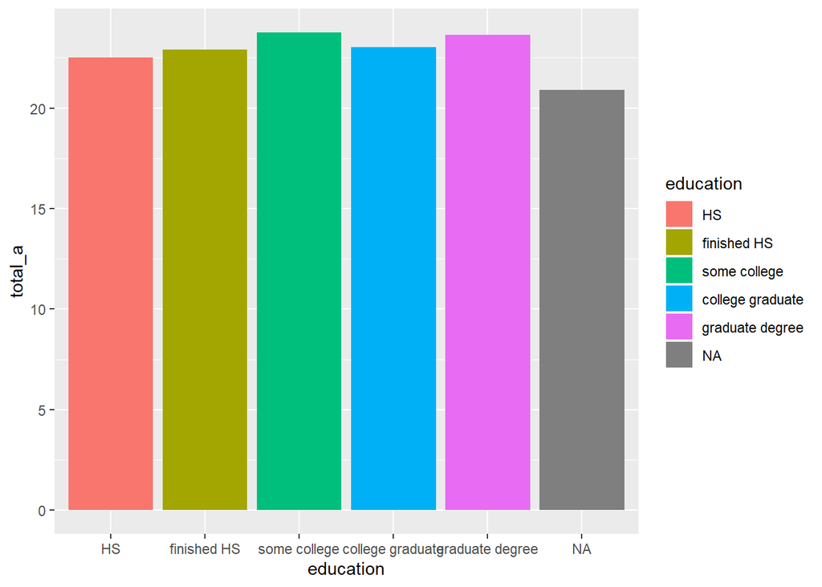

```r
mean_total_a <-
bfi_a %>%
  group_by(education) %>%
  summarise(total_a = mean(total_a, na.rm = TRUE))

ggplot(mean_total_a) +
  geom_col(aes(x = education, y = total_a, fill = education))
```

### 7.1.1 平均値の高い順に並び変え

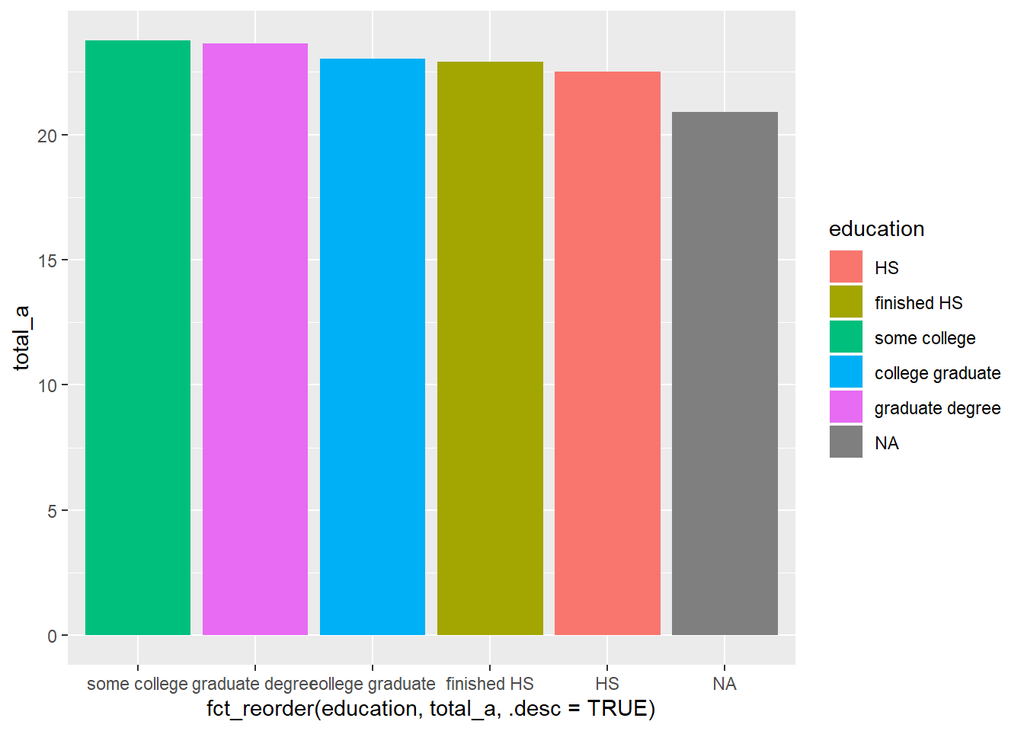

```r
ggplot(mean_total_a) +
  geom_col(aes(x = fct_reorder(education, total_a, .desc = TRUE),
               y = total_a, fill = education))
```

### 7.1.2 ラベル付与して見栄えを整える

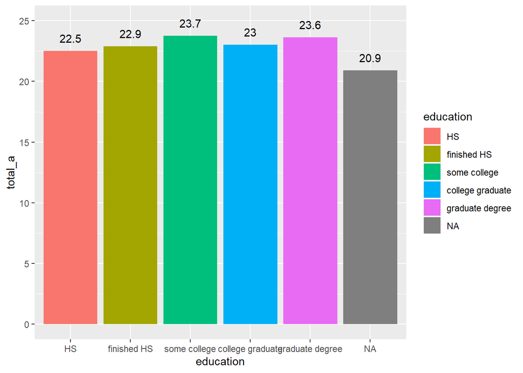

```r
ggplot(mean_total_a, aes(x = education, y = total_a, fill = education)) +
  geom_col() +
  geom_text(aes(label = round(total_a, 1)), vjust = -1) +
  scale_y_continuous(limits = c(0,25))
```

- `geom_text()`でラベル表示。`round()`で小数点第1位までにして，`vjust = -1`で棒グラフの上端から浮かせる設定に
- `scale_y_continuous()`で`limits =`により，y軸の表示範囲をラベルが全部表示できるように拡張

### 7.1.3 ラベル付与して見栄えを整える(2)

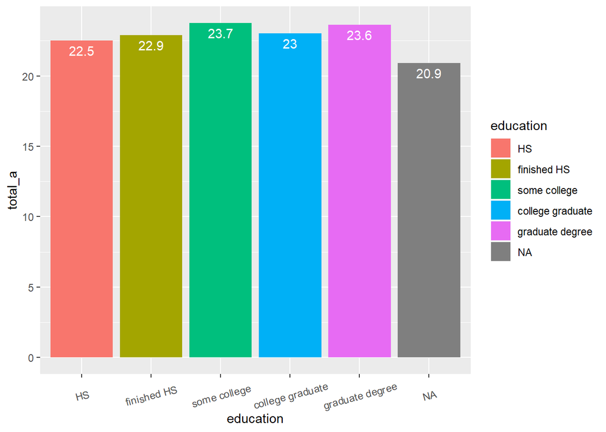

```r
ggplot(mean_total_a, aes(x = education, y = total_a, fill = education)) +
  geom_col() +
  geom_text(aes(label = round(total_a, 1)), vjust = 1.5,
            color = "white") +
  # scale_y_continuous(limits = c(0,25)) +
  theme(axis.text.x = element_text(angle = 15, vjust = 0.5))
```

### 7.1.4 グラフの色を変更

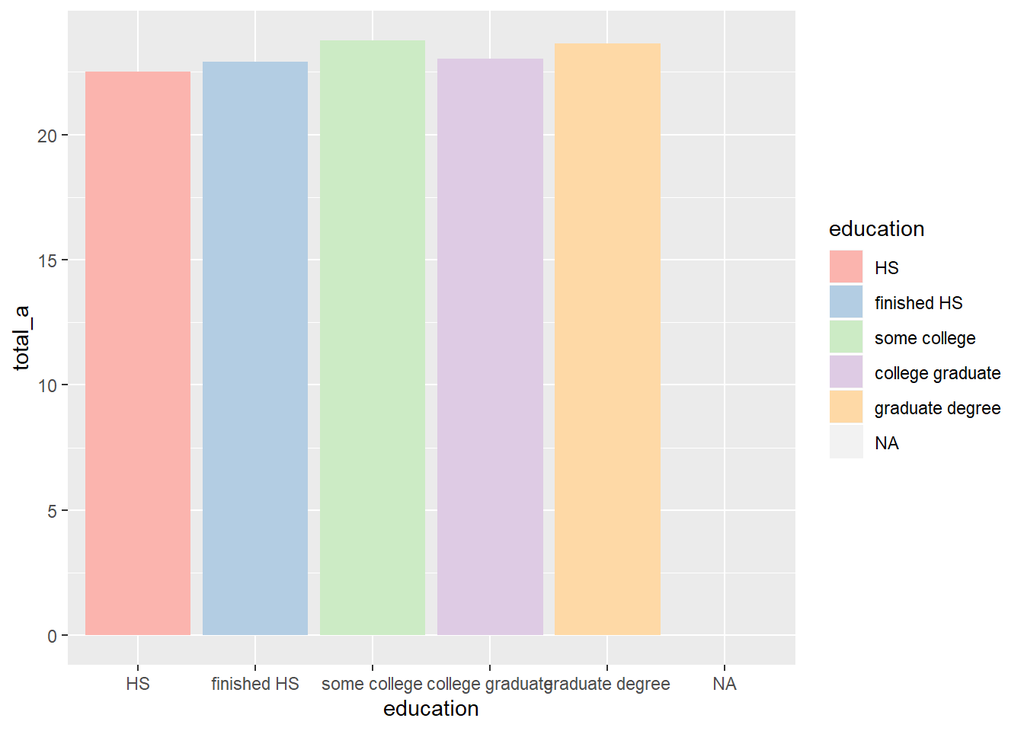

```r
ggplot(mean_total_a) +
  geom_col(aes(x = education, y = total_a, fill = education)) +
  scale_fill_brewer(palette = "Pastel1")
```

### 7.1.5 縦軸の数値の範囲変更

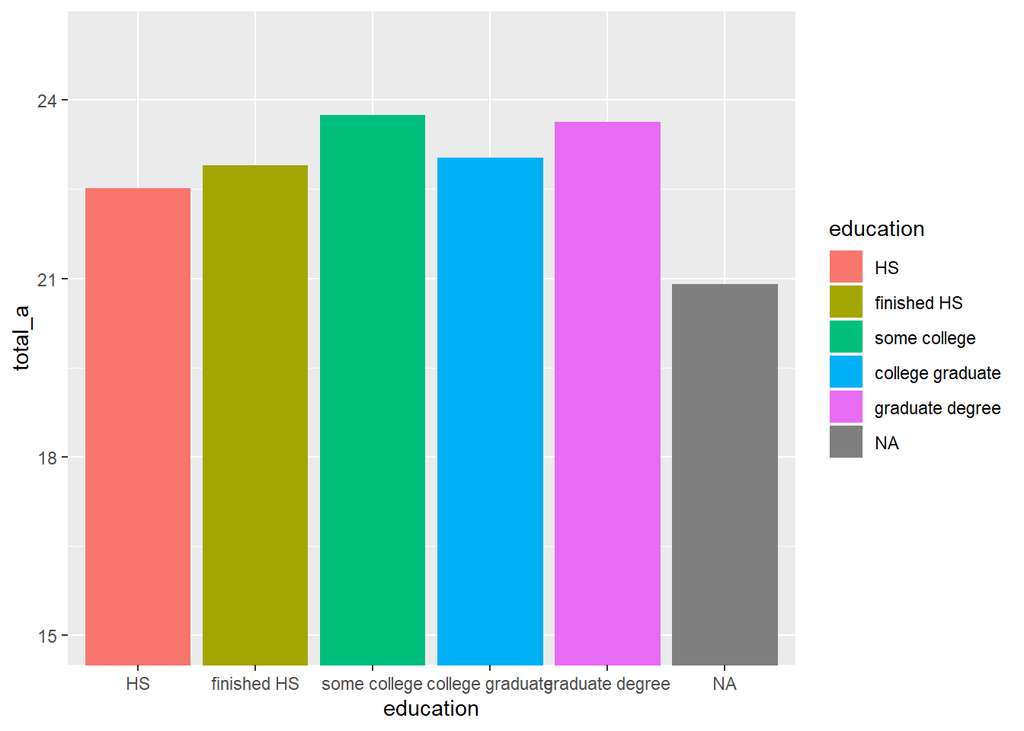

```r
ggplot(mean_total_a) +
  geom_col(aes(x = education, y = total_a, fill = education)) +
  scale_y_continuous(breaks = seq(15, 25, by = 3)) + # 横軸のラベル表示を15から25まで3ずつ
  coord_cartesian(ylim = c(15,25))                   # 横軸のデータ範囲表示を15から25までに限定
```

## 7.2 層別（2要因）の平均値の棒グラフ

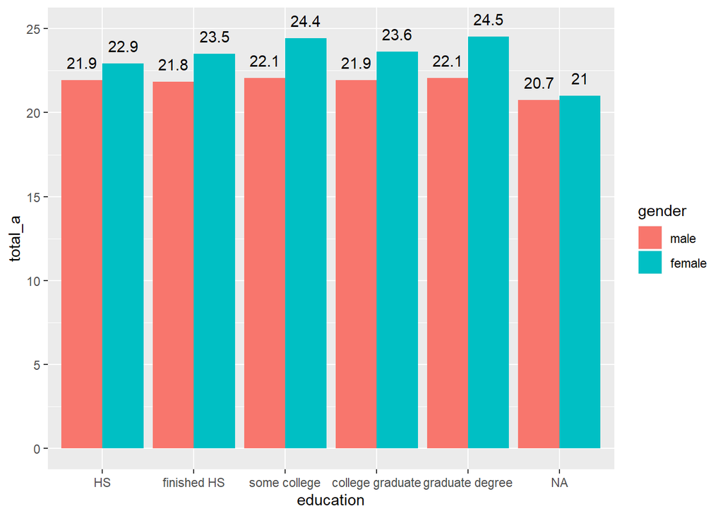

```r
mean_total_b <-
bfi_a %>%
  group_by(gender,education) %>%
  summarise(total_a = mean(total_a, na.rm = TRUE)) %>%
  ungroup()

ggplot(mean_total_b, aes(x = education, y = total_a, fill = gender)) +
  geom_col(position = "dodge") +
  geom_text(aes(label = round(total_a, 1)), vjust = -1,
            position = position_dodge(width = 0.9)) +
  scale_y_continuous(limits = c(0,25))
```

- `fill =`2つ目の要因を指定しただけだと，棒グラフは重なったまま。`geom_col(position = "dodge")`で棒グラフを区分
- `geom_text()`に引数`position = position_dodge( )`を指定すると，ラベルも区分されたグラフごとに表示される。デフォルトだと重なってしまっている。

### 7.2.1 層別（2要因）の平均値の棒グラフ(femaleの値で昇順ソート)

- NAは対象外

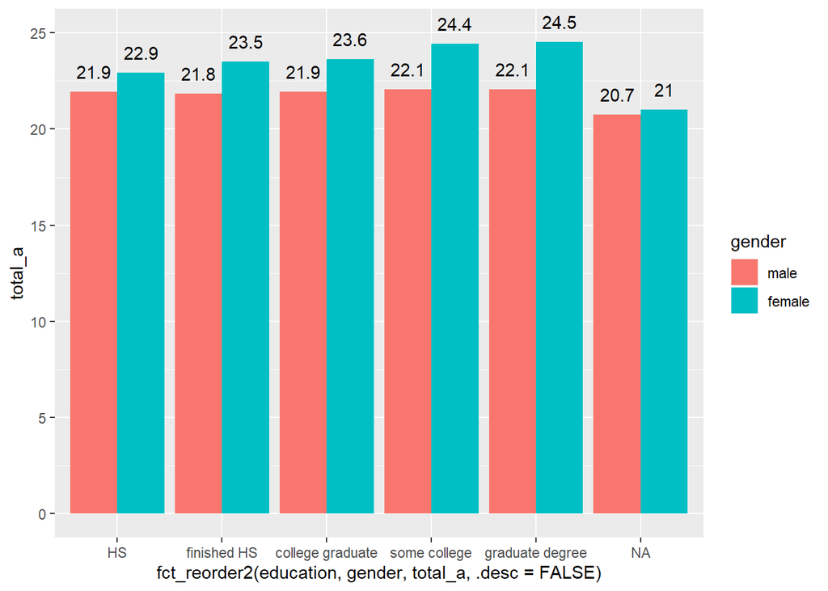

```r
ggplot(mean_total_b, aes(x = fct_reorder2(education, gender, total_a,                                         .desc = FALSE),
                         y = total_a, fill = gender)) +
  geom_col(position = "dodge") +
  geom_text(aes(label = round(total_a, 1)), vjust = -1,
            position = position_dodge(width = 0.9)) +
  scale_y_continuous(limits = c(0,25))
```

### 7.2.2 層別（2要因）の平均値の棒グラフ：基準線付き

- 線に被ってしまうラベルの位置調整

#### 7.2.2.1 被ったバージョン

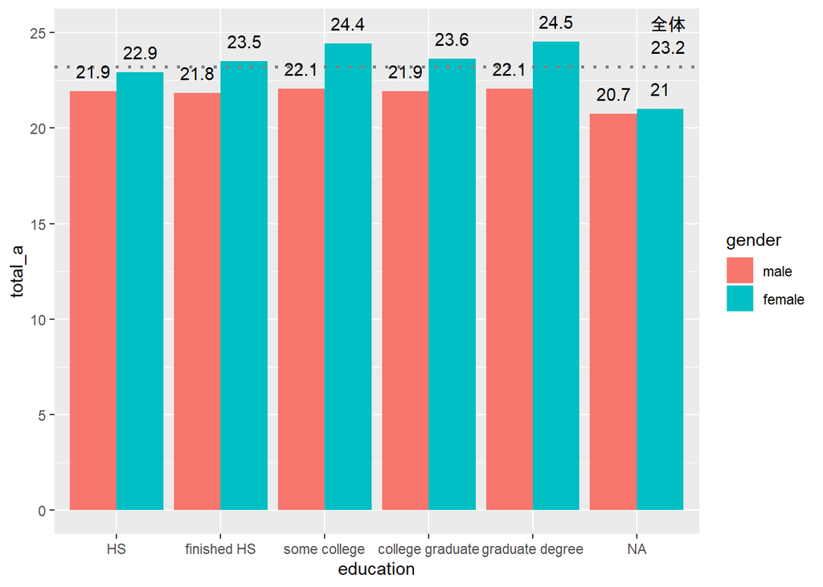

```r
mean_all <-
  bfi_a %>%
  summarise(total_a = mean(total_a, na.rm = TRUE)) %>%
  pull()

mean_total_b <-
bfi_a %>%
  group_by(gender,education) %>%
  summarise(total_a = mean(total_a, na.rm = TRUE))

ggplot(mean_total_b, aes(x = education, y = total_a, fill = gender)) +
  geom_col(position = "dodge") +
  geom_hline(yintercept = mean_all, linetype = "dotted",
             color = "gray50", size = 1) +
  geom_text(aes(label = round(total_a, 1)), vjust = -1,
            position = position_dodge(width = 0.9)) +
  annotate("text", x = 6.3, y = mean_all, vjust = -1,   # 全体平均値表示
           label = round(mean_all, 1)) +
  annotate("text", x = 6.3, y = mean_all + 1.2, vjust = -1,  # "全体"の文字表示
           label = "全体") +
  scale_y_continuous(limits = c(0,25))
```

#### 7.2.2.2 被ってないバージョン

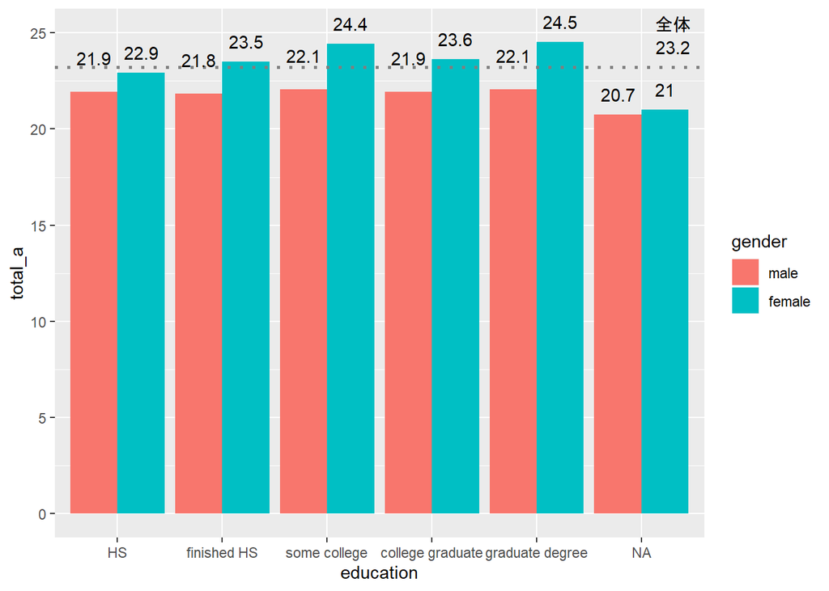

```r
ggplot(mean_total_b, aes(x = education, y = total_a, fill = gender)) +
  geom_col(position = "dodge") +
  geom_hline(yintercept = mean_all, linetype = "dotted",
             color = "gray50", size = 1) +
  geom_text(aes(label = round(total_a, 1),
                vjust = case_when(total_a <= (mean_all - 1) &     # 平均より-2点から-1点
                                  total_a >= (mean_all - 2) ~ -2, # 低かったら位置は-2
                                                       TRUE ~ -1) # その他の位置は-1
                ),
            position = position_dodge(width = 0.9)) +
  annotate("text", x = 6.3, y = mean_all, vjust = -1,
           label = round(mean_all, 1)) +
  annotate("text", x = 6.3, y = mean_all + 1.2, vjust = -1,
           label = "全体") +
  scale_y_continuous(limits = c(0,25))
```

## 7.4 ヒストグラム（カウント数ラベル付き）

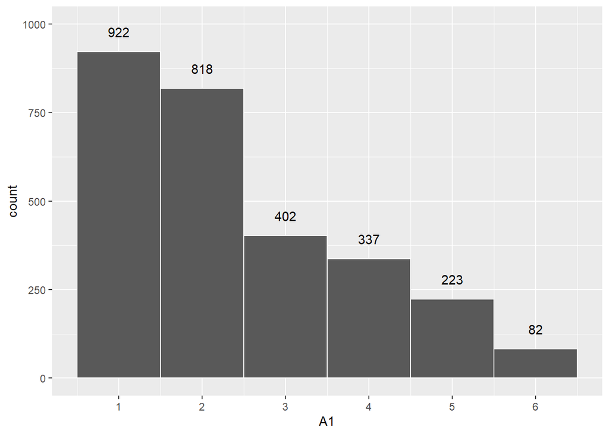

```r
ggplot(bfi, aes(A1)) +
  geom_histogram(bins = 6, color = "white") +      # binsは棒の数，colorは棒の線
  scale_x_continuous(breaks = seq(1, 6, by = 1)) + # 横軸の表示を1から6まで１ずつ
  stat_bin(bins = 6, geom="text", aes(label=..count..), vjust=-1.5) + # ラベル付与
  coord_cartesian(ylim = c(0,1000)) # デフォルトだとラベルが隠れてしまうので，縦軸広げる
```

- 縦軸表示の変更は`scale_y_continuous(limits = c(0, 1000))`でもいけた

## 7.5 facet_wrapで複数の図を一度に描くときに，複数ページに分割して表示する

- 大量に図を描くと1つ1つの図が小さくなって分かりにくい時があります。

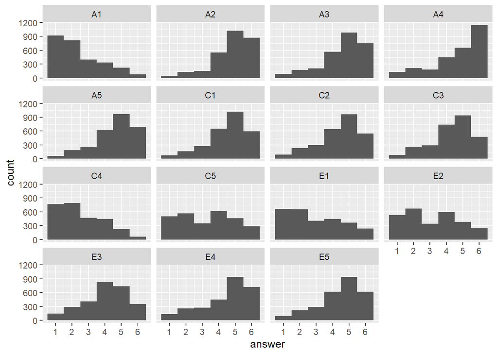

```r
bfi_long <-
bfi %>%
  select(A1:E5, gender:age) %>%
  gather(A1:E5, key = "items", value = "answer") %>%
  as_tibble()

ggplot(bfi_long) +
  geom_histogram(aes(answer), bins = 6) + # binsはデフォルトが30なので水準数と同じに設定
  scale_x_continuous(breaks = seq(1,6, by = 1)) + # x軸の値をすべて表示 1から6まで1ごと
  facet_wrap( ~ items)
```

- ggforceパッケージを使えば分割して表示できます
  - ここでは1ページ目を表示

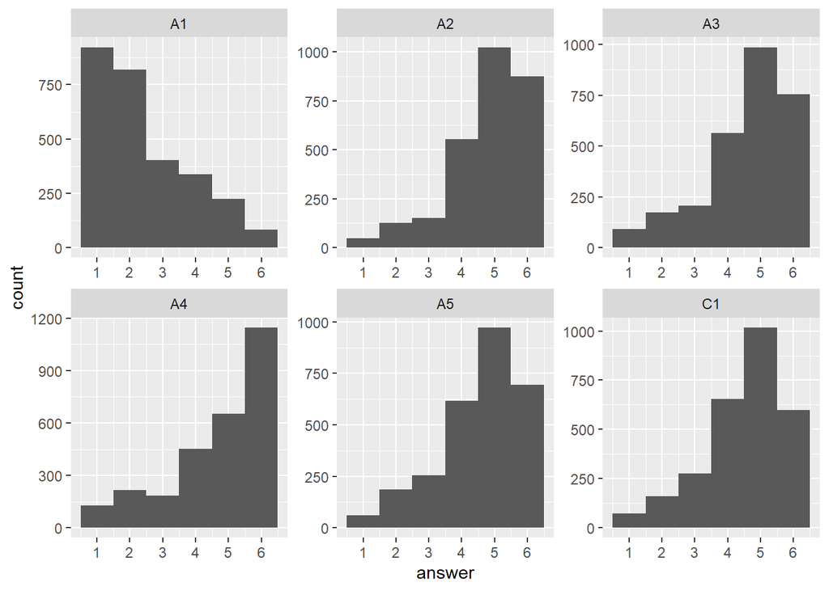

```r
library(ggforce)
ggplot(bfi_long) +
  geom_histogram(aes(answer), bins = 6) +
  scale_x_continuous(breaks = seq(1,6, by = 1)) +
  facet_wrap_paginate(~ items, nrow = 2, ncol = 3,  # ここに行と列の個数を指定
                      scales = "free", page = 1)    # 何ページ目を表示するか指定
```

- for loopを使って一度にすべて表示させます

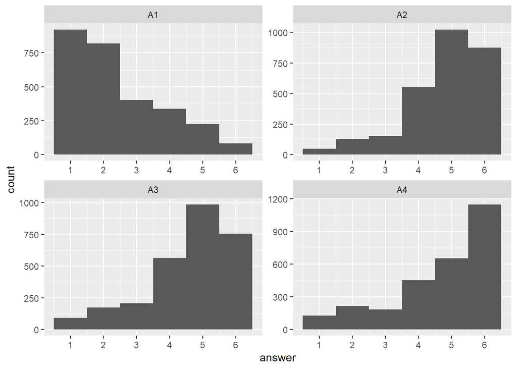

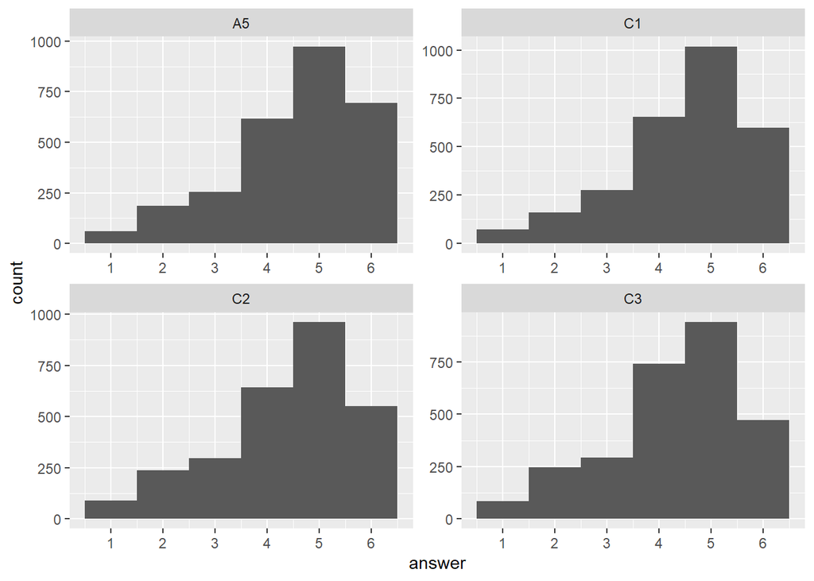

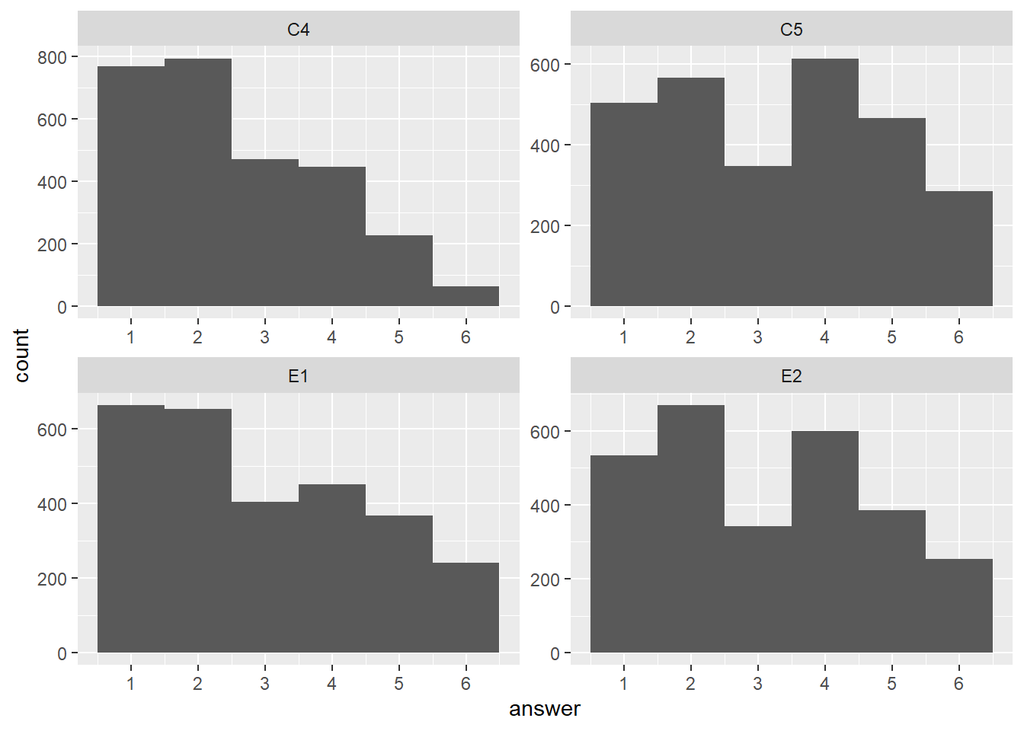

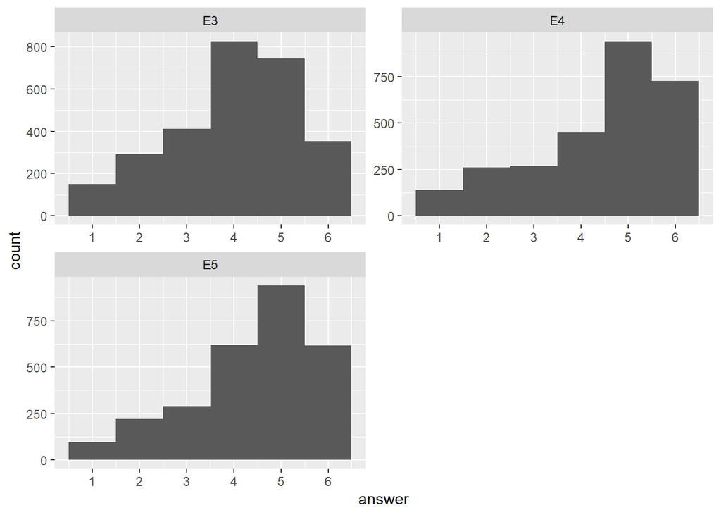

```r
for(i in 1:4){      # 作成されるページ数の範囲を指定
  print(
    ggplot(bfi_long) +
      geom_histogram(aes(answer), bins = 6) +
      scale_x_continuous(breaks = seq(1,6, by = 1)) +
      facet_wrap_paginate(~ items, nrow = 2, ncol = 2,
                          scales = "free", page = i)
  )
}
```

```r
# 自動で作成されるページ数を計算したい場合
# n_pages <- ceiling(
#   length(levels(bfi_long$items))/ 6)
```

## 7.6 散布図

- 散布図を描く意味があまりなさそうなデータなので図は省略

## 7.7 色がたくさん必要

### 7.7.1 RColorBrewerパッケージの既存パレット一覧

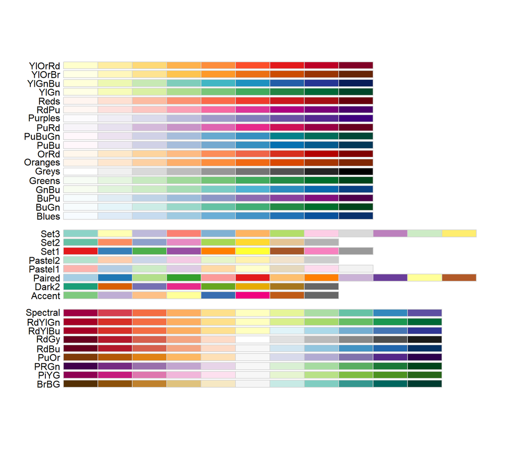

```r
library(RColorBrewer)
display.brewer.all()
```

### 7.7.2 ユニバーサルカラー

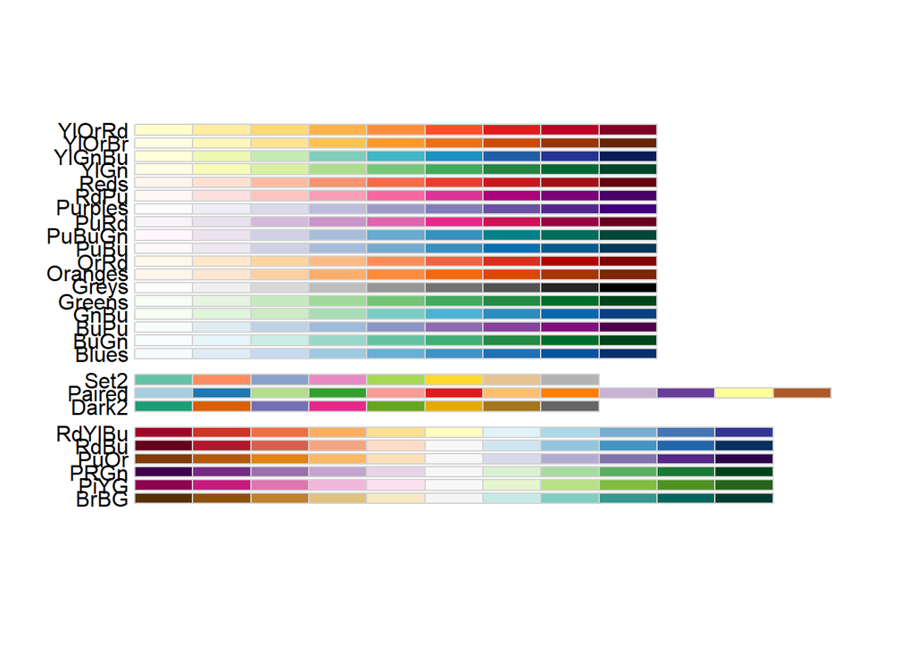

```r
display.brewer.all(colorblindFriendly= TRUE)
```

### 7.7.3 色を増やす

```r
# デフォルトではPairedは12色のみ
many_col <- brewer.pal(12, "Paired")
many_col
```

```
##  [1] "#A6CEE3" "#1F78B4" "#B2DF8A" "#33A02C" "#FB9A99" "#E31A1C" "#FDBF6F"
##  [8] "#FF7F00" "#CAB2D6" "#6A3D9A" "#FFFF99" "#B15928"
```

```r
# 20色まで増やす
many_col <- colorRampPalette(many_col)(20)
many_col
```

```
##  [1] "#A6CEE3" "#579CC7" "#3688AD" "#8BC395" "#89CB6C" "#40A635" "#919D5F"
##  [8] "#F99392" "#EB494A" "#E83C2D" "#F79C5D" "#FDA746" "#FE8205" "#E39970"
## [15] "#BFA5CF" "#8861AC" "#917099" "#E7E099" "#DEB969" "#B15928"
```

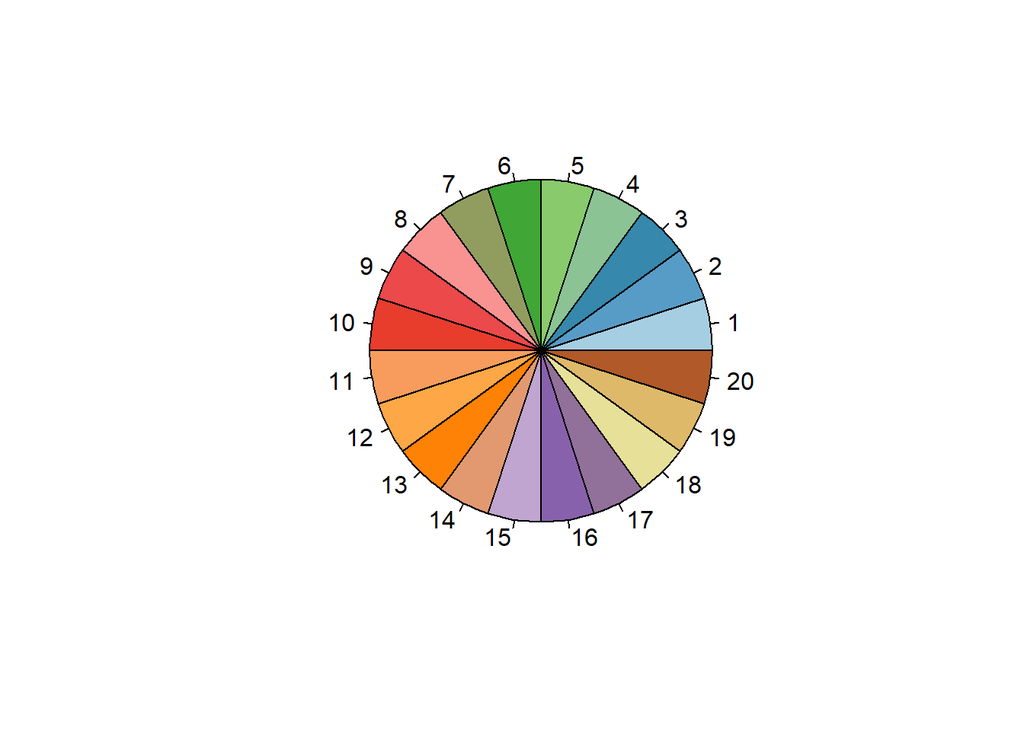

```r
pie(rep(1, length(many_col)), col = many_col, main = "")
```

### 7.7.4 デフォルトでたくさんあるpalsパッケージ

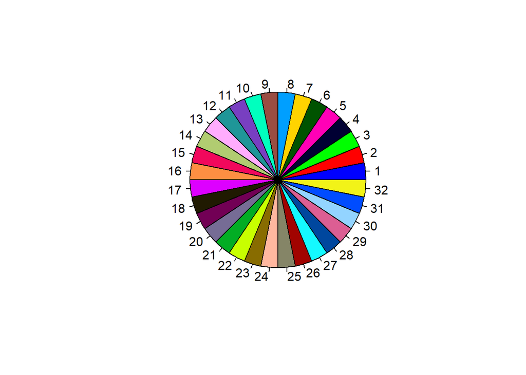

```r
library(pals)
many_col <- colorRampPalette(glasbey())(32)
pie(rep(1, length(many_col)), col = many_col, main = "")
```

## 7.8 ワッフルチャート

```r
# waffleパッケージをここだけで一時的に読んでいるためwaffle::としている


bfi %>%
  tabyl(gender)
```

```
##  gender    n   percent
##       1  919 0.3282143
##       2 1881 0.6717857
```

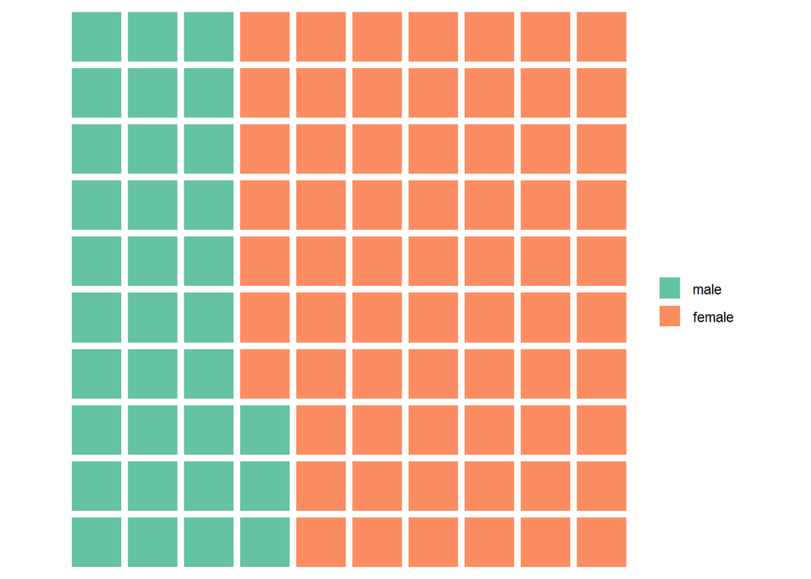

```r
parts <- c(male = 33, female = 67)
waffle::waffle(parts)
```

## 7.9 人型グラフ

- 割合を人型の図の数で示す

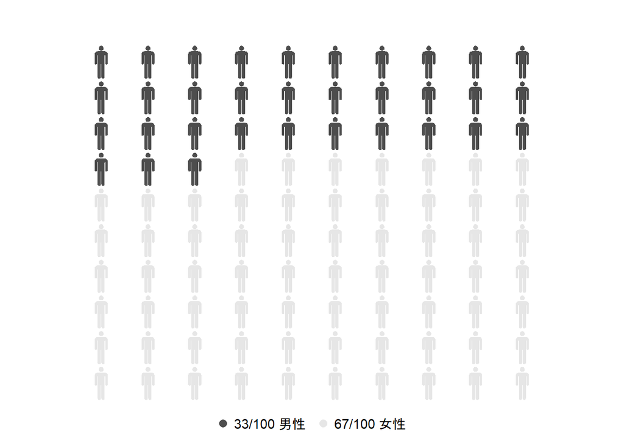

```r
# personographパッケージをここだけで一時的に読んでいるためpersonograph::としている
parts <- list(男性 = 0.33, 女性 = 0.67)
personograph::personograph(parts)
```

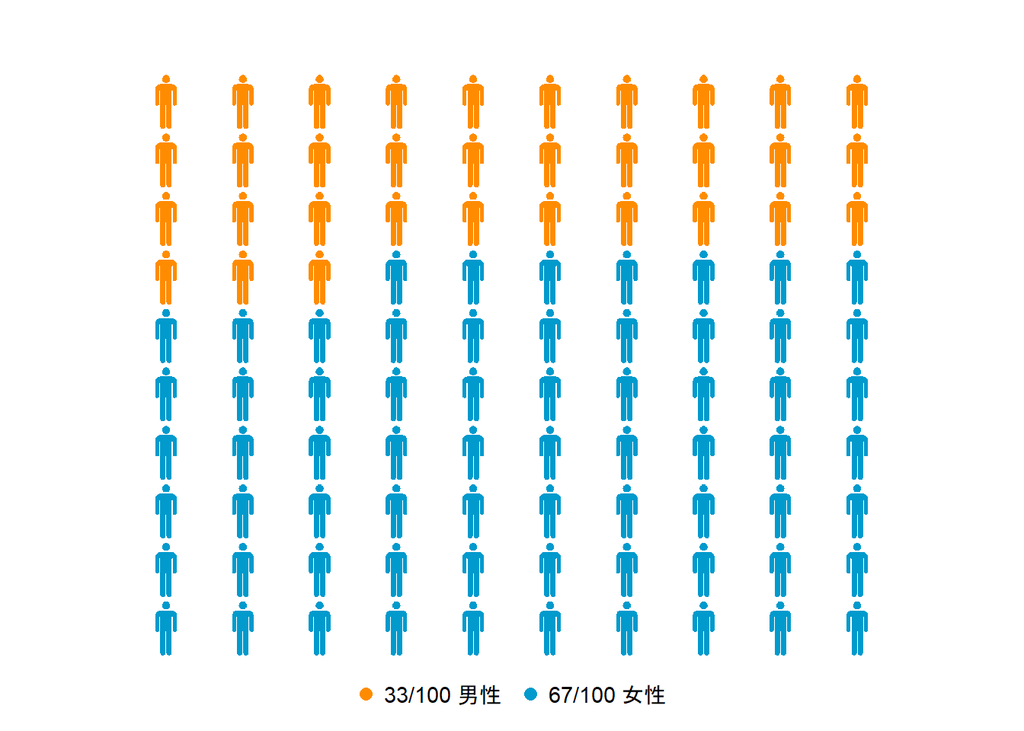

```r
personograph::personograph(parts,
                           colors = list(男性   = "darkorange",
                                         女性 = "deepskyblue3"))
```

# 8 相関

## 8.1 ピアソンの積率相関

```r
cor(bfi$A2, bfi$A3, use = "complete.obs")
```

```
## [1] 0.485098
```

## 8.2 相関行列

```r
bfi %>%
select(A1:A5) %>%
cor(use = "complete.obs")
```

```
##            A1         A2         A3         A4         A5
## A1  1.0000000 -0.3416242 -0.2682817 -0.1483927 -0.1826790
## A2 -0.3416242  1.0000000  0.4867503  0.3352432  0.3877875
## A3 -0.2682817  0.4867503  1.0000000  0.3621720  0.5051762
## A4 -0.1483927  0.3352432  0.3621720  1.0000000  0.3067003
## A5 -0.1826790  0.3877875  0.5051762  0.3067003  1.0000000
```

## 8.4 ポリコリック相関

- Polychoric correlation
- 順序尺度と順序尺度の相関

```r
res <-
bfi %>%
  select(A2, A3) %>%
  polychoric( na.rm = TRUE)

res
```

```
## Call: polychoric(x = ., na.rm = TRUE)
## Polychoric correlations
##    A2   A3
## A2 1.00
## A3 0.56 1.00
##
##  with tau of
##       1    2     3     4    5
## A2 -2.1 -1.5 -1.19 -0.48 0.48
## A3 -1.8 -1.3 -0.96 -0.33 0.61
```

```r
res$rho
```

```
##          A2       A3
## A2 1.000000 0.555451
## A3 0.555451 1.000000
```

```r
# 相関係数だけを取り出す
res$rho[1,2]
```

```
## [1] 0.555451
```

```r
# 因子型にした場合（結果は同じ）
# bfi %>%
#   select(A2, A3) %>%
#   mutate_all(factor) %>%
#   polychoric( na.rm = TRUE)
```

## 8.5 点双列相関

- point-biserial correlation
- 連続量と2値の相関

```r
# ltmパッケージをここだけで一時的に読んでいるためltm::としている
ltm::biserial.cor(bfi_a$total_a, bfi_a$gender, use = "complete.obs")
```

```
## [1] -0.2075376
```

```r
# ピアソンの積率相関で出した場合
bfi_a <-
  bfi_a %>%
  mutate(gender_n = as.numeric(gender))

cor(bfi_a$total_a, bfi_a$gender_n, use = "complete.obs")
```

```
## [1] 0.2075376
```

# 9 層別回帰

## 9.1 層別に重回帰

### 9.1.1 データフレームをネストする

```r
library(broom)


bfi_n <-
bfi %>%
  as_tibble %>%
  nest(-gender)

bfi_n
```

```
## # A tibble: 2 x 2
##   gender data
##    <int> <list>
## 1      1 <tibble [919 x 27]>
## 2      2 <tibble [1,881 x 27]>
```

### 9.1.2 回帰モデルをネストする

- 上から読んでいったら，`Error: Corrupt x: no names`が出たので，`map()`とぶつかりそうなパッケージをここで外す

```r
detach("package:pals", unload=TRUE)
# detach("package:maps", unload=TRUE) # 先にpalsを外さないと×
```

```r
bfi_n <-
bfi_n %>%
  mutate(
    fit = map(data, ~ lm(A5 ~ A1 + A4, data = .))
              )
bfi_n
```

```
## # A tibble: 2 x 3
##   gender data                  fit
##    <int> <list>                <list>
## 1      1 <tibble [919 x 27]>   <lm>
## 2      2 <tibble [1,881 x 27]> <lm>
```

```r
## 古いやり方
# fit <-
#   bfi %>%
#   group_by(gender) %>%
#   do(data = lm(A5 ~ A1 + A4 ,
#                data = .) %>%
#        tidy()
#   )
# res_fit <-
#   bfi_n %>%
#   unnest()
```

### 9.1.3 ネストを解除して回帰係数を出力

```r
res_fit <-
bfi_n %>%
  mutate(fit = map(fit, tidy)) %>%
  unnest(fit) %>%
  select(-data)


# tidyr 0.8.3までのやり方
# res_fit <-
# bfi_n %>%
#   unnest(fit %>% map(tidy))

res_fit
```

```
## # A tibble: 6 x 6
##   gender term        estimate std.error statistic   p.value
##    <int> <chr>          <dbl>     <dbl>     <dbl>     <dbl>
## 1      1 (Intercept)    3.53     0.160      22.0  3.09e- 86
## 2      1 A1            -0.132    0.0290     -4.54 6.24e-  6
## 3      1 A4             0.274    0.0279      9.81 1.14e- 21
## 4      2 (Intercept)    3.83     0.109      35.2  4.48e-208
## 5      2 A1            -0.113    0.0199     -5.71 1.34e-  8
## 6      2 A4             0.222    0.0186     11.9  1.01e- 31
```

### 9.1.4 ネストを解除してR二乗を出力

```r
bfi_n %>%
  mutate(fit = map(fit, glance)) %>%
  unnest(fit) %>%
  select(-data)
```

```
## # A tibble: 2 x 12
##   gender r.squared adj.r.squared sigma statistic  p.value    df logLik   AIC
##    <int>     <dbl>         <dbl> <dbl>     <dbl>    <dbl> <int>  <dbl> <dbl>
## 1      1    0.125         0.123   1.24      65.1 3.79e-27     3 -1485. 2979.
## 2      2    0.0968        0.0959  1.16      98.5 2.21e-41     3 -2881. 5769.
## # ... with 3 more variables: BIC <dbl>, deviance <dbl>, df.residual <int>
```

```r
# bfi_n %>%
#   unnest(fit %>% map(glance))
```

## 9.2 回帰係数を棒グラフで表示

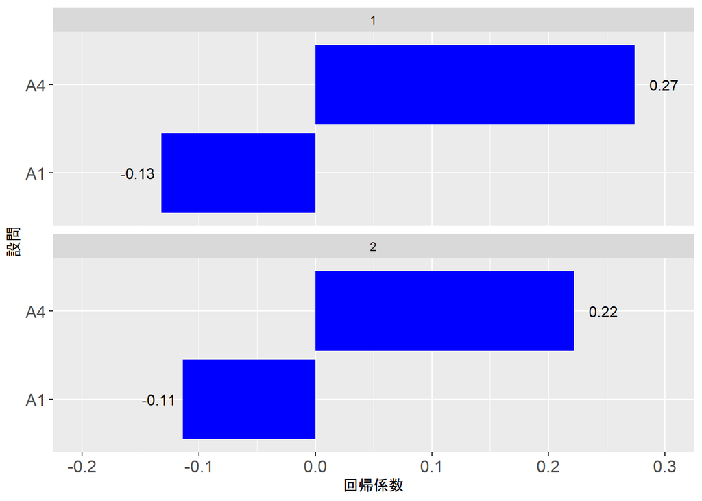

```r
res_fit %>%
  filter(term != "(Intercept)") %>%
  ggplot(aes(x = term, y = estimate)) +
  geom_col(fill = "blue") +
  geom_text(aes(label = round(estimate,2),
                hjust = if_else(estimate > 0, -0.5, 1.2) # 係数の値がマイナスだったら逆方向の位置に
                )
            ) +
    scale_y_continuous(limits = c(-0.2, 0.3)) +          # 軸の表示範囲を指定
  theme(
    axis.text.x = element_text(size = 12),               # x軸の文字の大きさ
    axis.text.y = element_text(size = 12)) +             # y軸の文字の大きさ
  labs(x = "設問", y = "回帰係数") +
   coord_flip() +                                        # グラフを横向きに（x軸とy軸が入れ替わる）
  facet_wrap(~ gender, ncol = 1)
```

## 9.3 回帰係数と信頼区間を表示

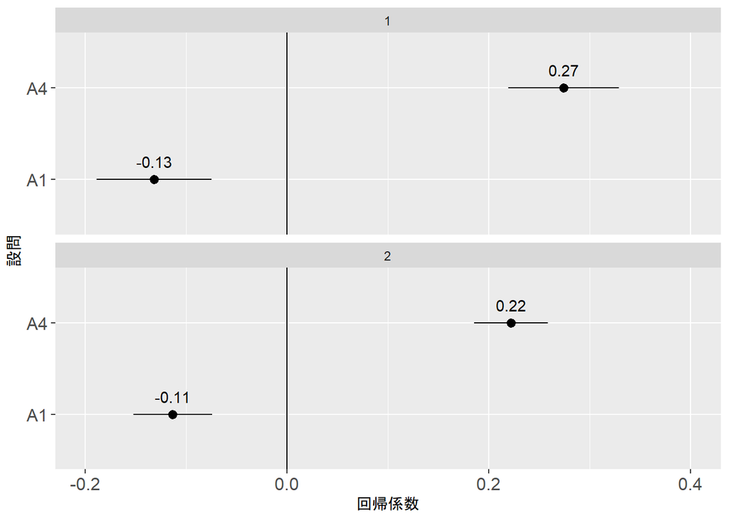

```r
res_fit <-
bfi_n %>%
  mutate(fit = map(fit, tidy, conf.int = TRUE)) %>%
  unnest(fit) %>%
  select(-data)


# res_fit <-
# bfi_n %>%
#   unnest(fit %>% map(tidy, conf.int = TRUE))


res_fit %>%
  filter(term != "(Intercept)") %>%
  ggplot(aes(x = term, y = estimate)) +
  geom_pointrange(aes(ymin = conf.low, ymax = conf.high)) +
  geom_text(aes(label = round(estimate,2),
                vjust = -1                        # 係数の値がマイナスだったら逆方向の位置に
                )
            ) +
  geom_hline(yintercept = 0) +                    # 係数が0の位置に線を表示
  scale_y_continuous(limits = c(-0.2, 0.4)) +     # 軸の表示範囲を指定
  theme(
    axis.text.x = element_text(size = 12),        # x軸の文字の大きさ
    axis.text.y = element_text(size = 12)) +      # y軸の文字の大きさ
  labs(x = "設問", y = "回帰係数") +
  coord_flip() +                                  # グラフを横向きに
  facet_wrap(~ gender, ncol = 1)
```

# 10 パッケージ管理

## 10.1 古いバージョンのパッケージをインストール

- https://stackoverflow.com/questions/17082341/installing-older-version-of-r-package

```r
library(devtools)
install_version("ggplot2", version = "0.9.1", repos = "http://cran.us.r-project.org")
```